# Dự đoán chỉ số khỏe mạnh dựa trên lối sống bằng hồi quy tuyến tính

Nhóm 26

11/02/2024

Gọi các thư viện cần dùng

```r
library(readr)
library(tidyverse)
```

```r
library(ggplot2)
library(janitor)
library(leaps)
library(boot)
library(mice)
library(VIM)
library(car)
library(ipred)
library(splines)
```

# 1. Bảng tóm tắt, khái quát về dữ liệu

```r
 data_health <- read_csv(file = "C:/Users/Huynh Ha Anh Thu/Downloads/synthetic_health_data.csv")
 data_health <- data_health |> janitor::clean_names()
 glimpse(data_health)
```

```
## Rows: 1,000
## Columns: 8
## $ age                 <dbl> 45.96057, 38.34083, 47.77226, 58.27636, 37.19016, …
## $ bmi                 <dbl> 31.99678, 29.62317, 25.29815, 21.76532, 28.49112, …
## $ exercise_frequency  <dbl> 5, 6, 5, 2, 2, 2, 5, 3, 4, 4, 1, 4, 4, 2, 2, 5, 1,…
## $ diet_quality        <dbl> 55.40327, 41.83836, 76.90495, 49.75677, 44.21874, …
## $ sleep_hours         <dbl> 7.300359, 7.012419, 6.028641, 5.802714, 7.912548, …
## $ smoking_status      <dbl> 0, 1, 1, 1, 0, 1, 0, 0, 1, 0, 1, 1, 0, 1, 1, 1, 1,…
## $ alcohol_consumption <dbl> 2.8347071, 7.1995168, 4.0979438, 3.6493772, 2.8397…
## $ health_score        <dbl> 70.54212, 57.24464, 96.33372, 61.32178, 67.17589, …
```

```r
aggr(data_health, ylab = c("Proportion of missings", "Pattern"), number = TRUE,
cex.axis = 0.6, cex.numbers = 0.5)
```

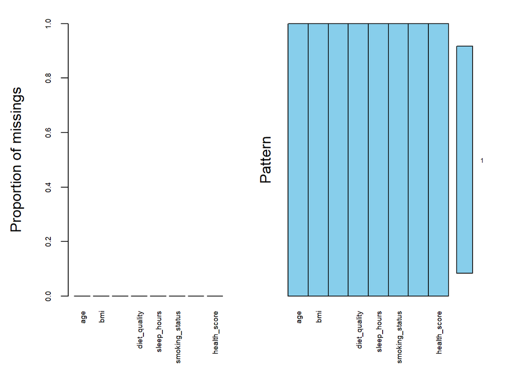

Dụa vào biểu đồ trên, ta thấy không có missing value trong bộ dữ liệu.

```r
summary(data_health)
```

```
##       age              bmi        exercise_frequency  diet_quality
##  Min.   : 1.105   Min.   :10.30   Min.   :0.000      Min.   : 19.91
##  1st Qu.:32.229   1st Qu.:21.97   1st Qu.:1.000      1st Qu.: 59.95
##  Median :40.304   Median :25.32   Median :3.000      Median : 69.98
##  Mean   :40.232   Mean   :25.35   Mean   :2.888      Mean   : 69.95
##  3rd Qu.:47.775   3rd Qu.:28.64   3rd Qu.:5.000      3rd Qu.: 80.53
##  Max.   :86.233   Max.   :40.97   Max.   :6.000      Max.   :110.27
##   sleep_hours     smoking_status  alcohol_consumption  health_score
##  Min.   : 2.431   Min.   :0.000   Min.   :-3.593      Min.   : 29.11
##  1st Qu.: 5.903   1st Qu.:0.000   1st Qu.: 1.644      1st Qu.: 76.43
##  Median : 6.991   Median :0.000   Median : 3.064      Median : 87.50
##  Mean   : 6.973   Mean   :0.499   Mean   : 3.079      Mean   : 85.48
##  3rd Qu.: 8.055   3rd Qu.:1.000   3rd Qu.: 4.489      3rd Qu.: 99.76
##  Max.   :11.639   Max.   :1.000   Max.   :11.105      Max.   :100.00
```

```r
# Đếm số giá trị âm trong cột alcohol_consumption
negative_values_count <- sum(data_health$alcohol_consumption < 0, na.rm = TRUE)
# In kết quả
cat("Số giá trị âm trong cột alcohol_consumption là:", negative_values_count, "\n")
```

```
## Số giá trị âm trong cột alcohol_consumption là: 70
```

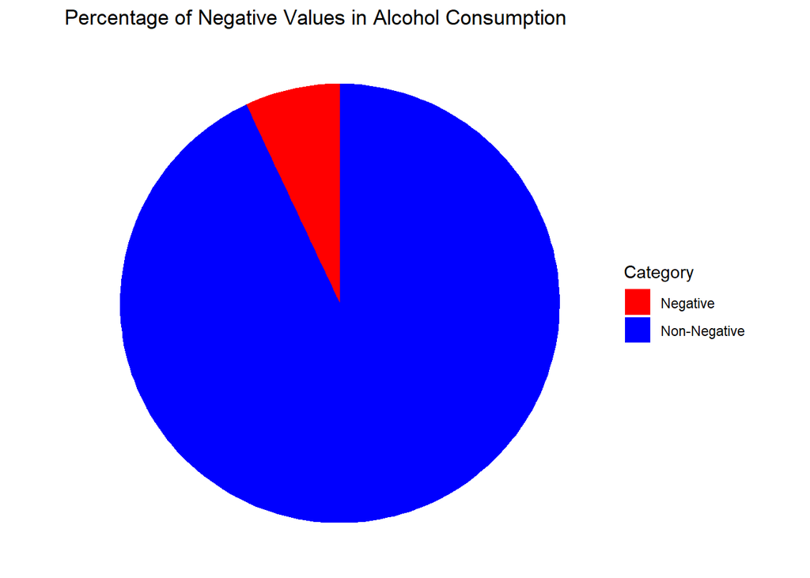

```r
# Tính phần trăm giá trị âm trong cột 'alcohol_consumption'
total_count <- nrow(data_health)
negative_count <- sum(data_health$alcohol_consumption < 0, na.rm = TRUE)  # Số giá trị âm
percent_negative <- (negative_count / total_count) * 100  # Phần trăm

# Tạo dataframe cho biểu đồ
percent_data <- data.frame(
  Category = c("Negative", "Non-Negative"),
  Percentage = c(percent_negative, 100 - percent_negative)
)

# Vẽ biểu đồ

ggplot(percent_data, aes(x = "", y = Percentage, fill = Category)) +
  geom_bar(stat = "identity", width = 1) +
  coord_polar("y") +
  labs(
    title = "Percentage of Negative Values in Alcohol Consumption",
    fill = "Category"
  ) +
  scale_fill_manual(values = c("Negative" = "red", "Non-Negative" = "blue")) +
  theme_void()
```

```r
percent_negative
```

```
## [1] 7
```

Vì lượng dữ liệu alcohol_consumption có giá trị âm < 10% nên ta xóa.

```r
# Xóa các giá trị âm trong cột alcohol_consumption
data_health <- data_health %>%
  filter(alcohol_consumption >= 0 | is.na(alcohol_consumption))

# Kiểm tra dữ liệu sau khi xóa
summary(data_health)
```

```
##       age              bmi        exercise_frequency  diet_quality
##  Min.   : 1.105   Min.   :10.30   Min.   :0.000      Min.   : 19.91
##  1st Qu.:32.245   1st Qu.:21.95   1st Qu.:1.000      1st Qu.: 59.79
##  Median :40.573   Median :25.30   Median :3.000      Median : 69.98
##  Mean   :40.398   Mean   :25.33   Mean   :2.863      Mean   : 69.91
##  3rd Qu.:47.872   3rd Qu.:28.61   3rd Qu.:5.000      3rd Qu.: 80.53
##  Max.   :86.233   Max.   :40.97   Max.   :6.000      Max.   :110.27
##   sleep_hours     smoking_status   alcohol_consumption  health_score
##  Min.   : 2.431   Min.   :0.0000   Min.   : 0.02608    Min.   : 29.11
##  1st Qu.: 5.927   1st Qu.:0.0000   1st Qu.: 1.94716    1st Qu.: 75.87
##  Median : 6.988   Median :1.0000   Median : 3.26350    Median : 87.15
##  Mean   : 6.965   Mean   :0.5043   Mean   : 3.37758    Mean   : 85.12
##  3rd Qu.: 8.047   3rd Qu.:1.0000   3rd Qu.: 4.59944    3rd Qu.: 99.33
##  Max.   :11.639   Max.   :1.0000   Max.   :11.10510    Max.   :100.00
```

```r
# Làm tròn cột 'age' về số nguyên gần nhất
data_health$age <- round(as.numeric(data_health$age))

# Xác nhận lại kiểu dữ liệu sau khi làm tròn
str(data_health)
```

```
## spc_tbl_ [930 × 8] (S3: spec_tbl_df/tbl_df/tbl/data.frame)
##  $ age                : num [1:930] 46 38 48 58 37 37 59 49 34 47 ...
##  $ bmi                : num [1:930] 32 29.6 25.3 21.8 28.5 ...
##  $ exercise_frequency : num [1:930] 5 6 5 2 2 2 5 3 4 4 ...
##  $ diet_quality       : num [1:930] 55.4 41.8 76.9 49.8 44.2 ...
##  $ sleep_hours        : num [1:930] 7.3 7.01 6.03 5.8 7.91 ...
##  $ smoking_status     : num [1:930] 0 1 1 1 0 1 0 0 1 0 ...
##  $ alcohol_consumption: num [1:930] 2.83 7.2 4.1 3.65 2.84 ...
##  $ health_score       : num [1:930] 70.5 57.2 96.3 61.3 67.2 ...
##  - attr(*, "spec")=
##   .. cols(
##   ..   Age = col_double(),
##   ..   BMI = col_double(),
##   ..   Exercise_Frequency = col_double(),
##   ..   Diet_Quality = col_double(),
##   ..   Sleep_Hours = col_double(),
##   ..   Smoking_Status = col_double(),
##   ..   Alcohol_Consumption = col_double(),
##   ..   Health_Score = col_double()
##   .. )
##  - attr(*, "problems")=<externalptr>
```

# 2. Xây dựng mô hình cho điểm sức khỏe.

## (1) Xử lý dữ liệu khuyết và kiểm tra đa cộng tuyến.

Phần xử lý dữ liệu khuyết đã được thực hiện ở trên.

Vẽ đồ thị phân tán của mỗi biến

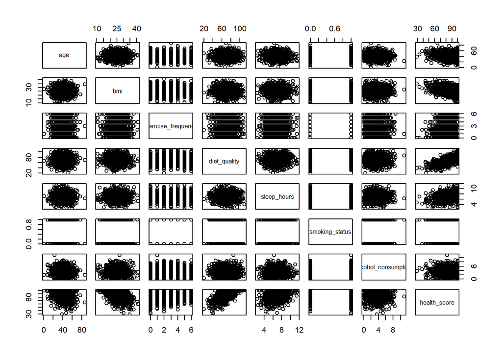

```r
pairs(data_health)
```

Ma trận tương quan của mô hình

```r
cor(data_health)
```

```
##                             age          bmi exercise_frequency diet_quality
## age                  1.00000000 -0.033899343        0.019364514 -0.012578410
## bmi                 -0.03389934  1.000000000        0.005971625 -0.049030063
## exercise_frequency   0.01936451  0.005971625        1.000000000 -0.027417596
## diet_quality        -0.01257841 -0.049030063       -0.027417596  1.000000000
## sleep_hours          0.02295933  0.035908484        0.014328767  0.003353287
## smoking_status       0.00600568 -0.037290891        0.021644345  0.013023207
## alcohol_consumption -0.06209985 -0.002772127        0.021140656  0.007304046
## health_score        -0.18520524 -0.420390409        0.237885188  0.689056514
##                      sleep_hours smoking_status alcohol_consumption
## age                  0.022959333     0.00600568        -0.062099845
## bmi                  0.035908484    -0.03729089        -0.002772127
## exercise_frequency   0.014328767     0.02164434         0.021140656
## diet_quality         0.003353287     0.01302321         0.007304046
## sleep_hours          1.000000000    -0.02297055        -0.010623356
## smoking_status      -0.022970553     1.00000000        -0.052631277
## alcohol_consumption -0.010623356    -0.05263128         1.000000000
## health_score         0.266081104    -0.10450250        -0.101512814
##                     health_score
## age                   -0.1852052
## bmi                   -0.4203904
## exercise_frequency     0.2378852
## diet_quality           0.6890565
## sleep_hours            0.2660811
## smoking_status        -0.1045025
## alcohol_consumption   -0.1015128
## health_score           1.0000000
```

```r
md_health = lm(health_score ~ age+bmi+exercise_frequency+diet_quality+sleep_hours+smoking_status+ alcohol_consumption,data = data_health)
vif(md_health)
```

```
##                 age                 bmi  exercise_frequency        diet_quality
##            1.006214            1.006332            1.002412            1.003576
##         sleep_hours      smoking_status alcohol_consumption
##            1.002704            1.005392            1.007410
```

Dựa vào kết quả trên, không bị xuất hiện đa cộng tuyến trong mô hình.

```r
data_health$smoking_status <- as.factor(data_health$smoking_status)
```

```r
data_health
```

```
## # A tibble: 930 × 8
##      age   bmi exercise_frequency diet_quality sleep_hours smoking_status
##    <dbl> <dbl>              <dbl>        <dbl>       <dbl> <fct>
##  1    46  32.0                  5         55.4        7.30 0
##  2    38  29.6                  6         41.8        7.01 1
##  3    48  25.3                  5         76.9        6.03 1
##  4    58  21.8                  2         49.8        5.80 1
##  5    37  28.5                  2         44.2        7.91 0
##  6    37  27.0                  2         89.1        7.79 1
##  7    59  29.5                  5         81.5        7.09 0
##  8    49  28.2                  3         65.0        8.39 0
##  9    34  30.2                  4         68.0        4.06 1
## 10    47  22.3                  4         33.9        6.15 0
## # ℹ 920 more rows
## # ℹ 2 more variables: alcohol_consumption <dbl>, health_score <dbl>
```

## (2) Xây dựng mô hình

Chạy mô hình ban đầu

```r
md_health = lm(health_score ~ age+bmi+exercise_frequency+diet_quality+sleep_hours+smoking_status+ alcohol_consumption,data = data_health)
summary(md_health)
```

```
##
## Call:
## lm(formula = health_score ~ age + bmi + exercise_frequency +
##     diet_quality + sleep_hours + smoking_status + alcohol_consumption,
##     data = data_health)
##
## Residuals:
##     Min      1Q  Median      3Q     Max
## -26.129  -3.383   0.598   3.837  14.993
##
## Coefficients:
##                     Estimate Std. Error t value Pr(>|t|)
## (Intercept)         62.98695    1.72522  36.510   <2e-16 ***
## age                 -0.24498    0.01545 -15.860   <2e-16 ***
## bmi                 -1.13151    0.03633 -31.144   <2e-16 ***
## exercise_frequency   1.83152    0.09120  20.082   <2e-16 ***
## diet_quality         0.61816    0.01207  51.218   <2e-16 ***
## sleep_hours          2.49856    0.11968  20.878   <2e-16 ***
## smoking_status1     -3.68488    0.36388 -10.127   <2e-16 ***
## alcohol_consumption -0.98054    0.09941  -9.863   <2e-16 ***
## ---
## Signif. codes:  0 '***' 0.001 '**' 0.01 '*' 0.05 '.' 0.1 ' ' 1
##
## Residual standard error: 5.533 on 922 degrees of freedom
## Multiple R-squared:  0.8403, Adjusted R-squared:  0.8391
## F-statistic:   693 on 7 and 922 DF,  p-value: < 2.2e-16
```

Dựa vào kết quả trên, ta có Adjusted R-squared: 0.8391 .

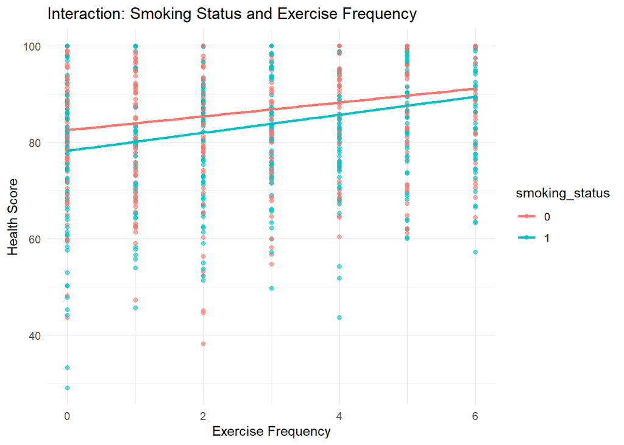

```r
ggplot(data_health, aes(x = exercise_frequency, y = health_score, color = smoking_status)) +
  geom_point(alpha = 0.6) +  # Điểm dữ liệu
  geom_smooth(method = "lm", se = FALSE) +  # Đường hồi quy riêng cho từng nhóm
  labs(title = "Interaction: Smoking Status and Exercise Frequency",
       x = "Exercise Frequency",
       y = "Health Score") +
  theme_minimal()
```

**Nhận xét**: Hai đường này gần như song song với nhau nên không có sự tương tác giữa smoking_status và exercise frequency

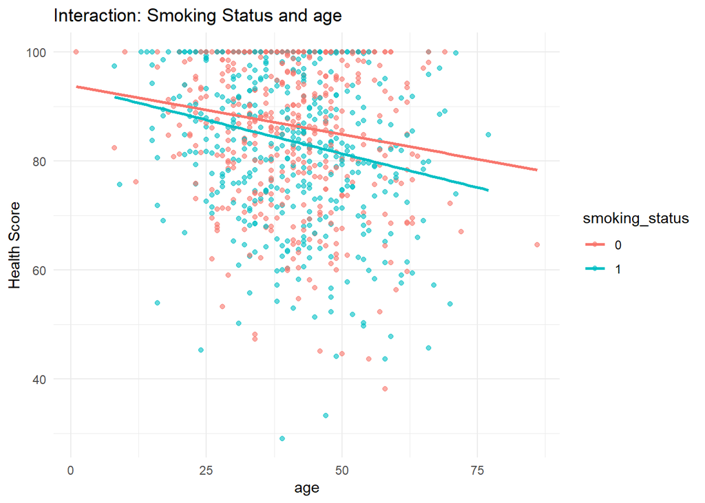

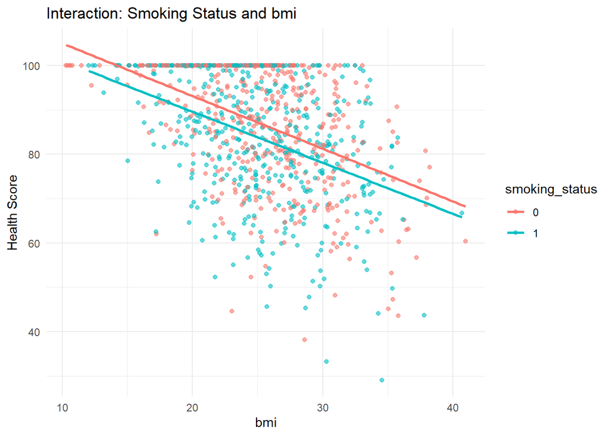

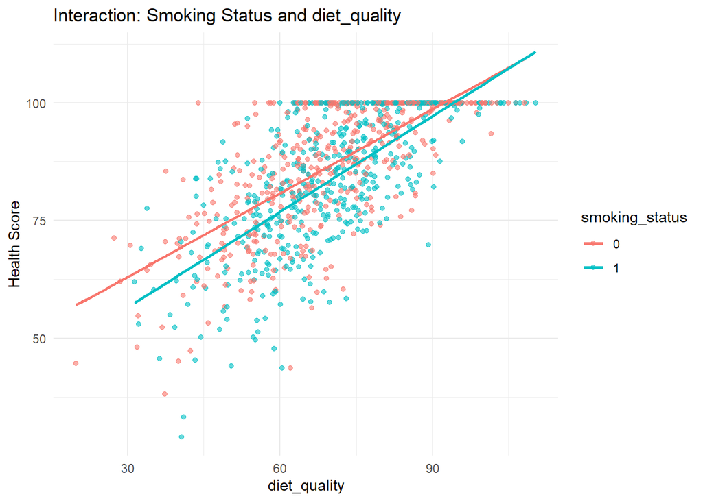

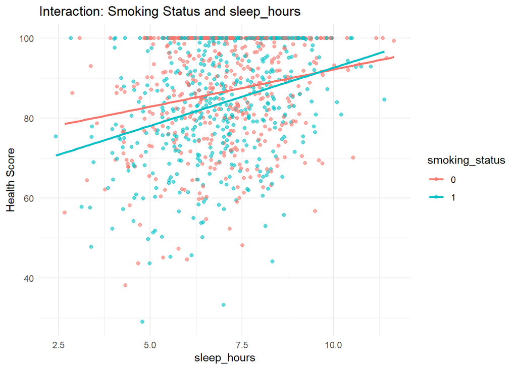

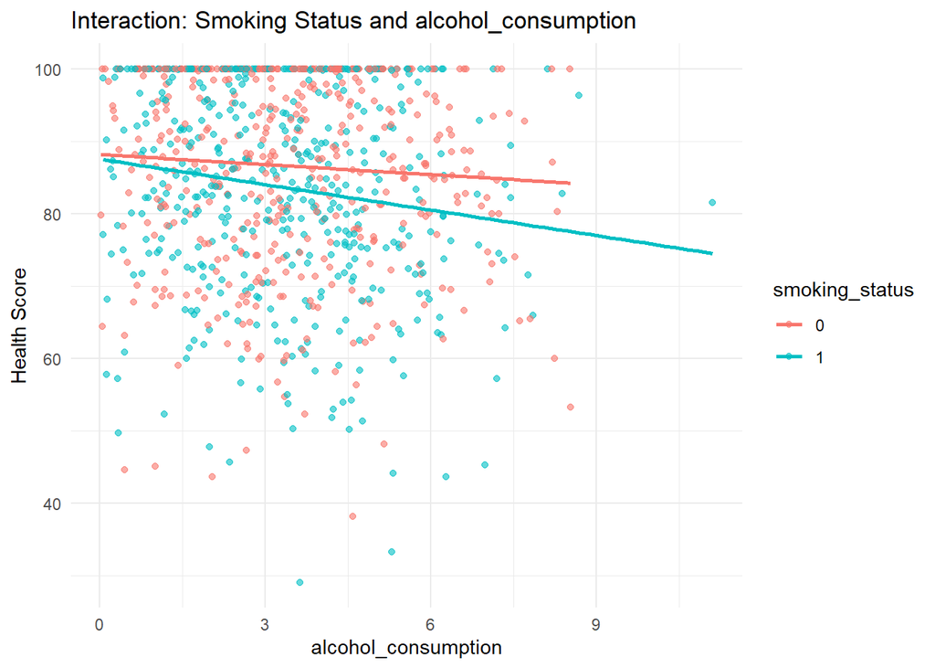

```r
vars <- c("age", "bmi", "diet_quality", "sleep_hours", "alcohol_consumption")

for (var in vars) {
  p <- ggplot(data_health, aes_string(x = var, y = "health_score", color = "smoking_status")) +
    geom_point(alpha = 0.6) +
    geom_smooth(method = "lm", se = FALSE) +
    labs(title = paste("Interaction: Smoking Status and", var),
         x = var,
         y = "Health Score") +
    theme_minimal()
  print(p)
}
```

**Nhận xét**:

Smoking_status và age: Có sự tương tác nhỏ trong độ tuổi từ 0-10 tuổi, tuy nhiên vẫn không có sự tương tác rõ rệt ở phần còn lại, cần phải kiểm tra kỹ bằng cách chạy mô hình.

Smoking_status và bmi: Hai đường thẳng này song song với nhau, vì thế không có sự tương tác giữa 2 thuộc tính này.

Smoking_status và sleep_hours: Hai đường thẳng có sự tương tác nhỏ khi giờ ngủ lớn 7.5 giờ.

Tiếp theo, nhóm em sẽ kiểm tra kết quả mô hình với biến tương tác.

```r
# Xây dựng mô hình hồi quy với tương tác giữa smoking_status và age
md_health_interaction <- lm(health_score ~ age * smoking_status + bmi + exercise_frequency +
                            diet_quality + sleep_hours + alcohol_consumption,
                            data = data_health)

# Kiểm tra kết quả hồi quy
summary(md_health_interaction)
```

```
##
## Call:
## lm(formula = health_score ~ age * smoking_status + bmi + exercise_frequency +
##     diet_quality + sleep_hours + alcohol_consumption, data = data_health)
##
## Residuals:
##      Min       1Q   Median       3Q      Max
## -26.2533  -3.4525   0.5362   3.8534  14.9184
##
## Coefficients:
##                     Estimate Std. Error t value Pr(>|t|)
## (Intercept)         62.52617    1.82493  34.262   <2e-16 ***
## age                 -0.23207    0.02270 -10.221   <2e-16 ***
## smoking_status1     -2.71398    1.30324  -2.082   0.0376 *
## bmi                 -1.13245    0.03636 -31.146   <2e-16 ***
## exercise_frequency   1.82899    0.09128  20.037   <2e-16 ***
## diet_quality         0.61805    0.01207  51.195   <2e-16 ***
## sleep_hours          2.49420    0.11983  20.814   <2e-16 ***
## alcohol_consumption -0.97790    0.09949  -9.829   <2e-16 ***
## age:smoking_status1 -0.02403    0.03098  -0.776   0.4380
## ---
## Signif. codes:  0 '***' 0.001 '**' 0.01 '*' 0.05 '.' 0.1 ' ' 1
##
## Residual standard error: 5.534 on 921 degrees of freedom
## Multiple R-squared:  0.8404, Adjusted R-squared:  0.839
## F-statistic: 606.2 on 8 and 921 DF,  p-value: < 2.2e-16
```

Dựa vào p_value của biến tương tác age:smoking_status1 là 0.4380 nên biến này không có ý nghĩa thống kê, đồng thời Adjusted R-squared: 0.839 thấp hơn so với mô hình không có biến tương tác

-> Không thêm biến tương tác này vào mô hình

```r
md_health_interaction <- lm(health_score ~ smoking_status * sleep_hours + age + bmi +
                            exercise_frequency + diet_quality + alcohol_consumption,
                            data = data_health)

# Kiểm tra kết quả hồi quy
summary(md_health_interaction)
```

```
##
## Call:
## lm(formula = health_score ~ smoking_status * sleep_hours + age +
##     bmi + exercise_frequency + diet_quality + alcohol_consumption,
##     data = data_health)
##
## Residuals:
##      Min       1Q   Median       3Q      Max
## -26.7857  -3.3711   0.5518   3.7736  15.1810
##
## Coefficients:
##                             Estimate Std. Error t value Pr(>|t|)
## (Intercept)                 64.42021    1.92754  33.421  < 2e-16 ***
## smoking_status1             -6.45420    1.70656  -3.782 0.000166 ***
## sleep_hours                  2.29393    0.17168  13.361  < 2e-16 ***
## age                         -0.24376    0.01545 -15.778  < 2e-16 ***
## bmi                         -1.13139    0.03630 -31.170  < 2e-16 ***
## exercise_frequency           1.82950    0.09112  20.077  < 2e-16 ***
## diet_quality                 0.61750    0.01206  51.185  < 2e-16 ***
## alcohol_consumption         -0.98103    0.09932  -9.878  < 2e-16 ***
## smoking_status1:sleep_hours  0.39759    0.23939   1.661 0.097081 .
## ---
## Signif. codes:  0 '***' 0.001 '**' 0.01 '*' 0.05 '.' 0.1 ' ' 1
##
## Residual standard error: 5.528 on 921 degrees of freedom
## Multiple R-squared:  0.8408, Adjusted R-squared:  0.8394
## F-statistic: 607.9 on 8 and 921 DF,  p-value: < 2.2e-16
```

Dựa vào p_value của biến tương tác smoking_status1:sleep_hours là 0.097081 nên biến này có ý nghĩa thống kê với mức ý nghĩa 10%, đồng thời Adjusted R-squared: 0.8394 có kết quả tốt hơn so với mô hình không có biến tương tác một chút.

-> Tuy nhiên vì p_value vẫn chưa thật sự là nhỏ nên vẫn còn xem xét kết hợp biến tương tác này với các biến khác và kiểm tra xem thử kết quả có tốt hơn không

```r
md_health_interaction <- lm(health_score ~ smoking_status * diet_quality + age + bmi +
                            exercise_frequency + sleep_hours + alcohol_consumption,
                            data = data_health)

# Kiểm tra kết quả hồi quy
summary(md_health_interaction)
```

```
##
## Call:
## lm(formula = health_score ~ smoking_status * diet_quality + age +
##     bmi + exercise_frequency + sleep_hours + alcohol_consumption,
##     data = data_health)
##
## Residuals:
##      Min       1Q   Median       3Q      Max
## -26.5693  -3.3743   0.6248   3.7468  15.0687
##
## Coefficients:
##                              Estimate Std. Error t value Pr(>|t|)
## (Intercept)                  65.03284    1.90398  34.156  < 2e-16 ***
## smoking_status1              -7.91048    1.72386  -4.589 5.07e-06 ***
## diet_quality                  0.58986    0.01650  35.753  < 2e-16 ***
## age                          -0.24451    0.01540 -15.873  < 2e-16 ***
## bmi                          -1.13255    0.03623 -31.260  < 2e-16 ***
## exercise_frequency            1.82762    0.09096  20.093  < 2e-16 ***
## sleep_hours                   2.48870    0.11940  20.843  < 2e-16 ***
## alcohol_consumption          -0.97645    0.09914  -9.849  < 2e-16 ***
## smoking_status1:diet_quality  0.06043    0.02410   2.507   0.0123 *
## ---
## Signif. codes:  0 '***' 0.001 '**' 0.01 '*' 0.05 '.' 0.1 ' ' 1
##
## Residual standard error: 5.517 on 921 degrees of freedom
## Multiple R-squared:  0.8414, Adjusted R-squared:   0.84
## F-statistic: 610.7 on 8 and 921 DF,  p-value: < 2.2e-16
```

Dựa vào p_value của biến tương tác smoking_status1:diet_quality là 0.0123 nên biến này có ý nghĩa thống kê, đồng thời Adjusted R-squared: 0.84 tốt hơn so với mô hình không có biến tương tác

-> Ta thêm biến tương tác này vào mô hình

```r
md_health_interaction <- lm(health_score ~ smoking_status * alcohol_consumption + age + bmi +
                            exercise_frequency + diet_quality + diet_quality,
                            data = data_health)

# Kiểm tra kết quả hồi quy
summary(md_health_interaction)
```

```
##
## Call:
## lm(formula = health_score ~ smoking_status * alcohol_consumption +
##     age + bmi + exercise_frequency + diet_quality + diet_quality,
##     data = data_health)
##
## Residuals:
##      Min       1Q   Median       3Q      Max
## -22.5205  -4.6356   0.5028   4.5767  17.5654
##
## Coefficients:
##                                     Estimate Std. Error t value Pr(>|t|)
## (Intercept)                         78.80087    1.92287  40.981  < 2e-16 ***
## smoking_status1                     -2.89051    0.92615  -3.121  0.00186 **
## alcohol_consumption                 -0.86262    0.16858  -5.117 3.78e-07 ***
## age                                 -0.23679    0.01873 -12.640  < 2e-16 ***
## bmi                                 -1.10189    0.04407 -25.002  < 2e-16 ***
## exercise_frequency                   1.86206    0.11061  16.834  < 2e-16 ***
## diet_quality                         0.61949    0.01464  42.325  < 2e-16 ***
## smoking_status1:alcohol_consumption -0.28615    0.24104  -1.187  0.23547
## ---
## Signif. codes:  0 '***' 0.001 '**' 0.01 '*' 0.05 '.' 0.1 ' ' 1
##
## Residual standard error: 6.71 on 922 degrees of freedom
## Multiple R-squared:  0.7652, Adjusted R-squared:  0.7634
## F-statistic: 429.1 on 7 and 922 DF,  p-value: < 2.2e-16
```

Dựa vào p_value của biến tương tác smoking_status1:alcohol_consumption là 0.23547 nên biến này không có ý nghĩa thống kê, đồng thời Adjusted R-squared: 0.7634 tệ hơn rất nhiều so với mô hình không có biến tương tác

-> Không thêm biến tương tác này nào mô hình

```r
md_health_interaction <- lm(health_score ~ smoking_status * diet_quality +
                            smoking_status * sleep_hours + age + bmi +
                            exercise_frequency + alcohol_consumption,
                            data = data_health)

# Kiểm tra kết quả hồi quy
summary(md_health_interaction)
```

```
##
## Call:
## lm(formula = health_score ~ smoking_status * diet_quality + smoking_status *
##     sleep_hours + age + bmi + exercise_frequency + alcohol_consumption,
##     data = data_health)
##
## Residuals:
##      Min       1Q   Median       3Q      Max
## -27.2204  -3.3136   0.5892   3.7322  15.2550
##
## Coefficients:
##                               Estimate Std. Error t value Pr(>|t|)
## (Intercept)                   66.45146    2.08637  31.850  < 2e-16 ***
## smoking_status1              -10.65075    2.38897  -4.458 9.28e-06 ***
## diet_quality                   0.58929    0.01649  35.744  < 2e-16 ***
## sleep_hours                    2.28538    0.17123  13.347  < 2e-16 ***
## age                           -0.24330    0.01541 -15.792  < 2e-16 ***
## bmi                           -1.13242    0.03620 -31.286  < 2e-16 ***
## exercise_frequency             1.82562    0.09088  20.089  < 2e-16 ***
## alcohol_consumption           -0.97695    0.09905  -9.863  < 2e-16 ***
## smoking_status1:diet_quality   0.06027    0.02408   2.503   0.0125 *
## smoking_status1:sleep_hours    0.39509    0.23871   1.655   0.0982 .
## ---
## Signif. codes:  0 '***' 0.001 '**' 0.01 '*' 0.05 '.' 0.1 ' ' 1
##
## Residual standard error: 5.512 on 920 degrees of freedom
## Multiple R-squared:  0.8419, Adjusted R-squared:  0.8403
## F-statistic: 544.1 on 9 and 920 DF,  p-value: < 2.2e-16
```

Đồng thời Adjusted R-squared: 0.8403 có cải thiện hơn so với mô hình không có biến tương tác

## (3) Lựa chọn mô hình

```r
out_subset_health <- regsubsets(x = health_score ~ . + smoking_status : diet_quality + smoking_status : sleep_hours, data = data_health, nvmax = 9, method = "exhaustive")
sum_out_subset_health <- summary(out_subset_health)
```

Đánh giá chỉ số Mallows’ Cp của các mô hình con

```r
sum_out_subset_health$cp
```

```
## [1] 2129.24460 1259.67388  812.30754  436.83608  202.19547  111.06648   15.03841
## [8]   10.73945   10.00000
```

Kết quả cho thấy tập kết quả thứ 9 (chứa 9 biến) là tốt nhất. Ước lượng hệ số của mô hình tương ứng với tập này

```r
best_model_formula <- coef(out_subset_health, which.min(sum_out_subset_health$cp))
```

Công thức của mô hình

```r
paste("health_score ~", paste(names(best_model_formula[-1]), collapse = " + "))
```

```
## [1] "health_score ~ age + bmi + exercise_frequency + diet_quality + sleep_hours + smoking_status1 + alcohol_consumption + diet_quality:smoking_status1 + sleep_hours:smoking_status1"
```

Xây dựng mô hình tuyến tính trên các biến vừa chọn

```r
md_health <- lm(health_score ~ . + smoking_status : diet_quality + smoking_status : sleep_hours, data_health)
summary(md_health)
```

```
##
## Call:
## lm(formula = health_score ~ . + smoking_status:diet_quality +
##     smoking_status:sleep_hours, data = data_health)
##
## Residuals:
##      Min       1Q   Median       3Q      Max
## -27.2204  -3.3136   0.5892   3.7322  15.2550
##
## Coefficients:
##                               Estimate Std. Error t value Pr(>|t|)
## (Intercept)                   66.45146    2.08637  31.850  < 2e-16 ***
## age                           -0.24330    0.01541 -15.792  < 2e-16 ***
## bmi                           -1.13242    0.03620 -31.286  < 2e-16 ***
## exercise_frequency             1.82562    0.09088  20.089  < 2e-16 ***
## diet_quality                   0.58929    0.01649  35.744  < 2e-16 ***
## sleep_hours                    2.28538    0.17123  13.347  < 2e-16 ***
## smoking_status1              -10.65075    2.38897  -4.458 9.28e-06 ***
## alcohol_consumption           -0.97695    0.09905  -9.863  < 2e-16 ***
## diet_quality:smoking_status1   0.06027    0.02408   2.503   0.0125 *
## sleep_hours:smoking_status1    0.39509    0.23871   1.655   0.0982 .
## ---
## Signif. codes:  0 '***' 0.001 '**' 0.01 '*' 0.05 '.' 0.1 ' ' 1
##
## Residual standard error: 5.512 on 920 degrees of freedom
## Multiple R-squared:  0.8419, Adjusted R-squared:  0.8403
## F-statistic: 544.1 on 9 and 920 DF,  p-value: < 2.2e-16
```

Đánh giá sai số **RMSE** bằng *errorest()* thông qua phương pháp cross-validation

```r
set.seed(123)
# 10-fold
error10 <- errorest(health_score ~ . + smoking_status : diet_quality + smoking_status : sleep_hours, data = data_health, model = lm)$error
# 5-fold
error5 <- errorest(health_score ~ . + smoking_status : diet_quality + smoking_status : sleep_hours, data = data_health, model = lm, est.para = control.errorest(k = 5))$error
# 50-fold
error50 <- errorest(health_score ~ . + smoking_status : diet_quality + smoking_status : sleep_hours, data = data_health, model = lm, est.para = control.errorest(k = 50))$error
error <- data.frame(
  k = c(5, 10, 50),
  CV = c(error5, error10, error50)
)
print(error)
```

```
##    k       CV
## 1  5 5.593394
## 2 10 5.580349
## 3 50 5.544703
```

## (4) Chẩn đoán mô hình

### Kiểm tra tính tuyến tính của mô hình

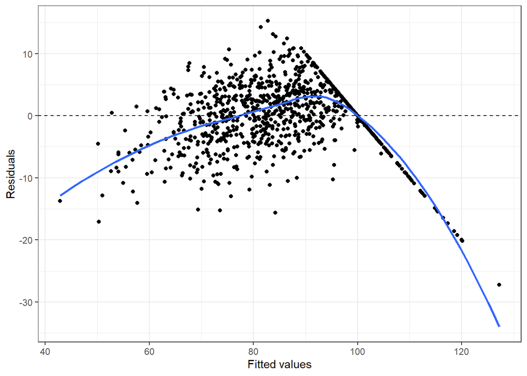

```r
ggplot(data = md_health, mapping = aes(x = .fitted, y= .resid)) +
  geom_point() +
  geom_smooth(method = "loess", se = FALSE) + # ve duong cong theo xu huong dl
  geom_hline(yintercept = 0, linetype = "dashed") +
  labs(x= "Fitted values", y= "Residuals") +
  theme_bw()
```

**Nhận xét:** Hình vẽ cho thấy một xu hướng đường cong rõ ràng

=> Giả định về tính tuyến tính của mô hình là không phù hợp

### Kiểm tra tính tuyến tính từng phần

1. Age

   ```r
   terms_md_health <- predict(md_health, type = "terms")
   head(terms_md_health)
   ```

   ```
   ##          age         bmi exercise_frequency diet_quality sleep_hours
   ## 1 -1.3627408 -7.54947926           3.900553    -8.549043   0.7675443
   ## 2  0.5836580 -4.86154949           5.726177   -16.542673   0.1094915
   ## 3 -1.8493405  0.03619985           3.900553     4.121622  -2.1388141
   ## 4 -4.2823390  4.03686519          -1.576318   -11.876455  -2.6551414
   ## 5  0.8269579 -3.57958765          -1.576318   -15.139946   2.1666275
   ## 6  0.8269579 -1.85412607          -1.576318    11.322646   1.8785344
   ##   smoking_status alcohol_consumption diet_quality:smoking_status
   ## 1       5.371186           0.5303580                  -2.1306732
   ## 2      -5.279566          -3.7338325                   0.3907841
   ## 3      -5.279566          -0.7037582                   2.5041299
   ## 4      -5.279566          -0.2655320                   0.8680001
   ## 5       5.371186           0.5253872                  -2.1306732
   ## 6      -5.279566           1.7427003                   3.2405815
   ##   sleep_hours:smoking_status
   ## 1                 -1.3807491
   ## 2                  1.3897854
   ## 3                  1.0011047
   ## 4                  0.9118435
   ## 5                 -1.3807491
   ## 6                  1.6956126
   ```

   ```r
   partial_resid_md_health <- residuals(md_health, type = "partial")
   head(partial_resid_md_health)
   ```

   ```
   ##         age         bmi exercise_frequency diet_quality sleep_hours
   ## 1 -5.537672 -11.7244100        -0.27437792    -12.72397  -3.4073865
   ## 2 -5.074076 -10.5192838         0.06844217    -22.20041  -5.5482428
   ## 3  7.772154   9.6576944        13.52204745     13.74312   7.4826805
   ## 4 -7.962011   0.3571935        -5.25598971    -15.55613  -6.3348131
   ## 5 -2.200130  -6.6066751        -4.60340548    -18.16703  -0.8604599
   ## 6  3.709838   1.0287537         1.30656168     14.20553   4.7614142
   ##   smoking_status alcohol_consumption diet_quality:smoking_status
   ## 1       1.196255           -3.644573                   -6.305604
   ## 2     -10.937301           -9.391567                   -5.266950
   ## 3       4.341928            8.917736                   12.125624
   ## 4      -8.959238           -3.945204                   -2.811672
   ## 5       2.344098           -2.501700                   -5.157761
   ## 6      -2.396687            4.625580                    6.123461
   ##   sleep_hours:smoking_status
   ## 1                  -5.555680
   ## 2                  -4.267949
   ## 3                  10.622599
   ## 4                  -2.767828
   ## 5                  -4.407837
   ## 6                   4.578492
   ```

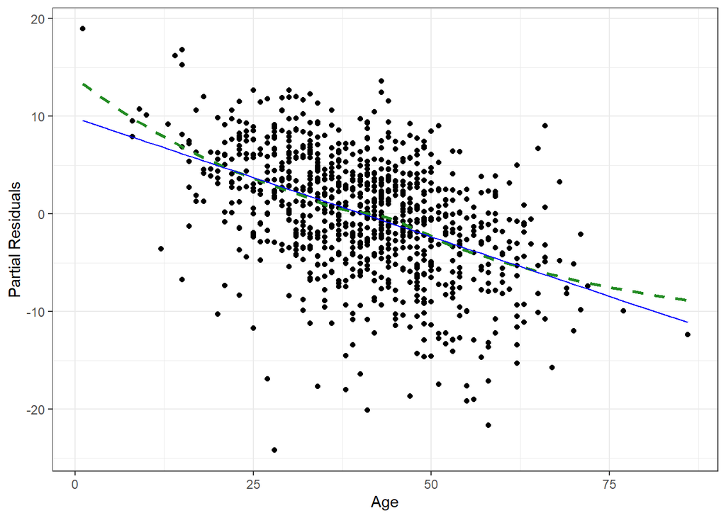

   ```r
   data_part_resid_age_md_health <- tibble(
     age = data_health$age,
     terms_age = terms_md_health[, "age"],
     partial_resid_age = partial_resid_md_health[, "age"]
   )

   ggplot(data_part_resid_age_md_health, mapping = aes(age, partial_resid_age)) +
     geom_point()+
     geom_smooth(method = "loess", se = FALSE, linetype = "dashed",
                 color = "forestgreen") +
     geom_line(aes(x = age, y = terms_age), color = "blue") +
     labs(x = "Age", y = "Partial Residuals") +
     theme_bw()
   ```

**Kết luận:** Mối quan hệ giữa Age và phần dư là gần tuyến tính, nhưng có thể cải thiện nếu sử dụng các biến phi tuyến như spline

2. BMI

   ```r
   terms_md_health <- predict(md_health, type = "terms")
   head(terms_md_health)
   ```

   ```
   ##          age         bmi exercise_frequency diet_quality sleep_hours
   ## 1 -1.3627408 -7.54947926           3.900553    -8.549043   0.7675443
   ## 2  0.5836580 -4.86154949           5.726177   -16.542673   0.1094915
   ## 3 -1.8493405  0.03619985           3.900553     4.121622  -2.1388141
   ## 4 -4.2823390  4.03686519          -1.576318   -11.876455  -2.6551414
   ## 5  0.8269579 -3.57958765          -1.576318   -15.139946   2.1666275
   ## 6  0.8269579 -1.85412607          -1.576318    11.322646   1.8785344
   ##   smoking_status alcohol_consumption diet_quality:smoking_status
   ## 1       5.371186           0.5303580                  -2.1306732
   ## 2      -5.279566          -3.7338325                   0.3907841
   ## 3      -5.279566          -0.7037582                   2.5041299
   ## 4      -5.279566          -0.2655320                   0.8680001
   ## 5       5.371186           0.5253872                  -2.1306732
   ## 6      -5.279566           1.7427003                   3.2405815
   ##   sleep_hours:smoking_status
   ## 1                 -1.3807491
   ## 2                  1.3897854
   ## 3                  1.0011047
   ## 4                  0.9118435
   ## 5                 -1.3807491
   ## 6                  1.6956126
   ```

   ```r
   partial_resid_md_health <- residuals(md_health, type = "partial")
   head(partial_resid_md_health)
   ```

   ```
   ##         age         bmi exercise_frequency diet_quality sleep_hours
   ## 1 -5.537672 -11.7244100        -0.27437792    -12.72397  -3.4073865
   ## 2 -5.074076 -10.5192838         0.06844217    -22.20041  -5.5482428
   ## 3  7.772154   9.6576944        13.52204745     13.74312   7.4826805
   ## 4 -7.962011   0.3571935        -5.25598971    -15.55613  -6.3348131
   ## 5 -2.200130  -6.6066751        -4.60340548    -18.16703  -0.8604599
   ## 6  3.709838   1.0287537         1.30656168     14.20553   4.7614142
   ##   smoking_status alcohol_consumption diet_quality:smoking_status
   ## 1       1.196255           -3.644573                   -6.305604
   ## 2     -10.937301           -9.391567                   -5.266950
   ## 3       4.341928            8.917736                   12.125624
   ## 4      -8.959238           -3.945204                   -2.811672
   ## 5       2.344098           -2.501700                   -5.157761
   ## 6      -2.396687            4.625580                    6.123461
   ##   sleep_hours:smoking_status
   ## 1                  -5.555680
   ## 2                  -4.267949
   ## 3                  10.622599
   ## 4                  -2.767828
   ## 5                  -4.407837
   ## 6                   4.578492
   ```

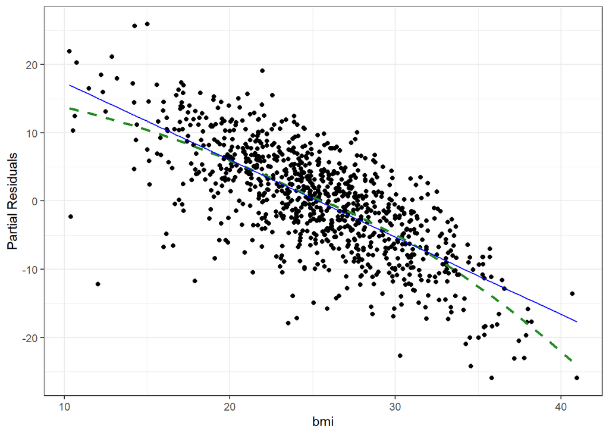

   ```r
   data_part_resid_bmi_md_health <- tibble(
     bmi = data_health$bmi,
     terms_bmi = terms_md_health[, "bmi"],
     partial_resid_bmi = partial_resid_md_health[, "bmi"]
   )

   ggplot(data_part_resid_bmi_md_health, mapping = aes(bmi, partial_resid_bmi)) +
     geom_point()+
     geom_smooth(method = "loess", se = FALSE, linetype = "dashed",
                 color = "forestgreen") +
     geom_line(aes(x = bmi, y = terms_bmi), color = "blue") +
     labs(x = "bmi", y = "Partial Residuals") +
     theme_bw()
   ```

**Nhận xét:** Đường thẳng màu xanh cho thấy mối quan hệ tuyến tính khá tốt. Đường cong xanh lục chỉ ra sự phi tuyến nhẹ ở giá trị BMI > 35, với sự overestimate nhẹ.

**Kết luận:** Mối quan hệ giữa BMI và phần dư là gần tuyến tính. Một số phi tuyến nhẹ nhưng không đáng kể. => Cân nhắc đưa vào spline

3. exercise_frequency

   ```r
   terms_md_health <- predict(md_health, type = "terms")
   head(terms_md_health)
   ```

   ```
   ##          age         bmi exercise_frequency diet_quality sleep_hours
   ## 1 -1.3627408 -7.54947926           3.900553    -8.549043   0.7675443
   ## 2  0.5836580 -4.86154949           5.726177   -16.542673   0.1094915
   ## 3 -1.8493405  0.03619985           3.900553     4.121622  -2.1388141
   ## 4 -4.2823390  4.03686519          -1.576318   -11.876455  -2.6551414
   ## 5  0.8269579 -3.57958765          -1.576318   -15.139946   2.1666275
   ## 6  0.8269579 -1.85412607          -1.576318    11.322646   1.8785344
   ##   smoking_status alcohol_consumption diet_quality:smoking_status
   ## 1       5.371186           0.5303580                  -2.1306732
   ## 2      -5.279566          -3.7338325                   0.3907841
   ## 3      -5.279566          -0.7037582                   2.5041299
   ## 4      -5.279566          -0.2655320                   0.8680001
   ## 5       5.371186           0.5253872                  -2.1306732
   ## 6      -5.279566           1.7427003                   3.2405815
   ##   sleep_hours:smoking_status
   ## 1                 -1.3807491
   ## 2                  1.3897854
   ## 3                  1.0011047
   ## 4                  0.9118435
   ## 5                 -1.3807491
   ## 6                  1.6956126
   ```

   ```r
   partial_resid_md_health <- residuals(md_health, type = "partial")
   head(partial_resid_md_health)
   ```

   ```
   ##         age         bmi exercise_frequency diet_quality sleep_hours
   ## 1 -5.537672 -11.7244100        -0.27437792    -12.72397  -3.4073865
   ## 2 -5.074076 -10.5192838         0.06844217    -22.20041  -5.5482428
   ## 3  7.772154   9.6576944        13.52204745     13.74312   7.4826805
   ## 4 -7.962011   0.3571935        -5.25598971    -15.55613  -6.3348131
   ## 5 -2.200130  -6.6066751        -4.60340548    -18.16703  -0.8604599
   ## 6  3.709838   1.0287537         1.30656168     14.20553   4.7614142
   ##   smoking_status alcohol_consumption diet_quality:smoking_status
   ## 1       1.196255           -3.644573                   -6.305604
   ## 2     -10.937301           -9.391567                   -5.266950
   ## 3       4.341928            8.917736                   12.125624
   ## 4      -8.959238           -3.945204                   -2.811672
   ## 5       2.344098           -2.501700                   -5.157761
   ## 6      -2.396687            4.625580                    6.123461
   ##   sleep_hours:smoking_status
   ## 1                  -5.555680
   ## 2                  -4.267949
   ## 3                  10.622599
   ## 4                  -2.767828
   ## 5                  -4.407837
   ## 6                   4.578492
   ```

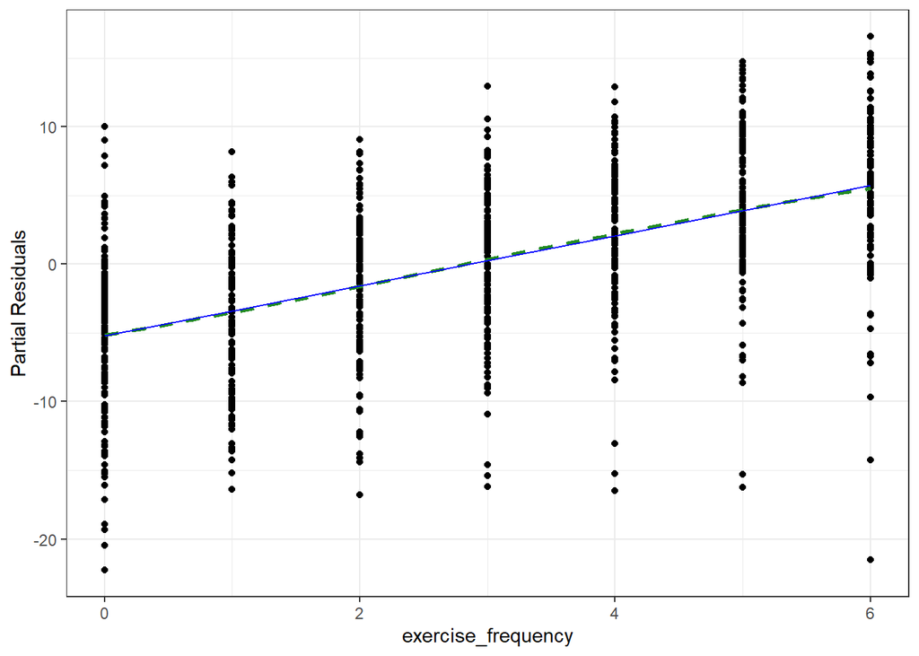

   ```r
   data_part_resid_exercise_frequency_md_health <- tibble(
     exercise_frequency = data_health$exercise_frequency,
     terms_exercise_frequency = terms_md_health[, "exercise_frequency"],
     partial_resid_exercise_frequency = partial_resid_md_health[, "exercise_frequency"]
   )

   ggplot(data_part_resid_exercise_frequency_md_health, mapping = aes(exercise_frequency, partial_resid_exercise_frequency)) +
     geom_point()+
     geom_smooth(method = "loess", se = FALSE, linetype = "dashed",
                 color = "forestgreen") +
     geom_line(aes(x = exercise_frequency, y = terms_exercise_frequency), color = "blue") +
     labs(x = "exercise_frequency", y = "Partial Residuals") +
     theme_bw()
   ```

**Nhận xét:** Đường thẳng màu xanh cho thấy một xu hướng tăng nhẹ giữa exercise_frequency và phần dư từng phần. Mối quan hệ giữa exercise_frequency và phần dư từng phần là gần tuyến tính, được thể hiện qua đường thẳng xanh lam. Phi tuyến nhẹ: đường cong xanh lục gần như trùng khớp với đường thẳng xanh lam, cho thấy không có sự phi tuyến đáng kể.

**Kết luận:** exercise_frequency có đóng góp đáng kể trong mô hình hồi quy, và mối quan hệ tuyến tính hiện tại là phù hợp.

4. diet_quality

   ```r
   terms_md_health <- predict(md_health, type = "terms")
   head(terms_md_health)
   ```

   ```
   ##          age         bmi exercise_frequency diet_quality sleep_hours
   ## 1 -1.3627408 -7.54947926           3.900553    -8.549043   0.7675443
   ## 2  0.5836580 -4.86154949           5.726177   -16.542673   0.1094915
   ## 3 -1.8493405  0.03619985           3.900553     4.121622  -2.1388141
   ## 4 -4.2823390  4.03686519          -1.576318   -11.876455  -2.6551414
   ## 5  0.8269579 -3.57958765          -1.576318   -15.139946   2.1666275
   ## 6  0.8269579 -1.85412607          -1.576318    11.322646   1.8785344
   ##   smoking_status alcohol_consumption diet_quality:smoking_status
   ## 1       5.371186           0.5303580                  -2.1306732
   ## 2      -5.279566          -3.7338325                   0.3907841
   ## 3      -5.279566          -0.7037582                   2.5041299
   ## 4      -5.279566          -0.2655320                   0.8680001
   ## 5       5.371186           0.5253872                  -2.1306732
   ## 6      -5.279566           1.7427003                   3.2405815
   ##   sleep_hours:smoking_status
   ## 1                 -1.3807491
   ## 2                  1.3897854
   ## 3                  1.0011047
   ## 4                  0.9118435
   ## 5                 -1.3807491
   ## 6                  1.6956126
   ```

   ```r
   partial_resid_md_health <- residuals(md_health, type = "partial")
   head(partial_resid_md_health)
   ```

   ```
   ##         age         bmi exercise_frequency diet_quality sleep_hours
   ## 1 -5.537672 -11.7244100        -0.27437792    -12.72397  -3.4073865
   ## 2 -5.074076 -10.5192838         0.06844217    -22.20041  -5.5482428
   ## 3  7.772154   9.6576944        13.52204745     13.74312   7.4826805
   ## 4 -7.962011   0.3571935        -5.25598971    -15.55613  -6.3348131
   ## 5 -2.200130  -6.6066751        -4.60340548    -18.16703  -0.8604599
   ## 6  3.709838   1.0287537         1.30656168     14.20553   4.7614142
   ##   smoking_status alcohol_consumption diet_quality:smoking_status
   ## 1       1.196255           -3.644573                   -6.305604
   ## 2     -10.937301           -9.391567                   -5.266950
   ## 3       4.341928            8.917736                   12.125624
   ## 4      -8.959238           -3.945204                   -2.811672
   ## 5       2.344098           -2.501700                   -5.157761
   ## 6      -2.396687            4.625580                    6.123461
   ##   sleep_hours:smoking_status
   ## 1                  -5.555680
   ## 2                  -4.267949
   ## 3                  10.622599
   ## 4                  -2.767828
   ## 5                  -4.407837
   ## 6                   4.578492
   ```

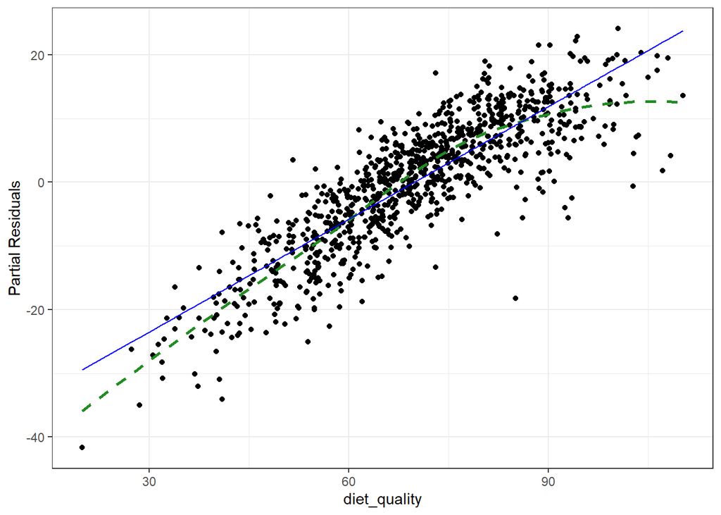

   ```r
   data_part_resid_diet_quality_md_health <- tibble(
     diet_quality  = data_health$diet_quality ,
     terms_diet_quality  = terms_md_health[, "diet_quality"],
     partial_resid_diet_quality  = partial_resid_md_health[, "diet_quality"]
   )

   ggplot(data_part_resid_diet_quality_md_health, mapping = aes(diet_quality , partial_resid_diet_quality)) +
     geom_point()+
     geom_smooth(method = "loess", se = FALSE, linetype = "dashed",
                 color = "forestgreen") +
     geom_line(aes(x = diet_quality , y = terms_diet_quality ), color = "blue") +
     labs(x = "diet_quality", y = "Partial Residuals") +
     theme_bw()
   ```

**Nhận xét:** Đường thẳng màu xanh phù hợp khá tốt với dữ liệu, nhưng có một số phi tuyến nhẹ ở các giá trị diet_quality < 40 và diet_quality > 90. Đường cong xanh lục thể hiện sự phi tuyến ở các phần dư ngoài rìa.

**Kết luận:** Mối quan hệ giữa diet_quality và phần dư là tuyến tính, nhưng có thể cải thiện bằng cách thêm biến phi tuyến nếu cần.

5. sleep_hours

   ```r
   terms_md_health <- predict(md_health, type = "terms")
   head(terms_md_health)
   ```

   ```
   ##          age         bmi exercise_frequency diet_quality sleep_hours
   ## 1 -1.3627408 -7.54947926           3.900553    -8.549043   0.7675443
   ## 2  0.5836580 -4.86154949           5.726177   -16.542673   0.1094915
   ## 3 -1.8493405  0.03619985           3.900553     4.121622  -2.1388141
   ## 4 -4.2823390  4.03686519          -1.576318   -11.876455  -2.6551414
   ## 5  0.8269579 -3.57958765          -1.576318   -15.139946   2.1666275
   ## 6  0.8269579 -1.85412607          -1.576318    11.322646   1.8785344
   ##   smoking_status alcohol_consumption diet_quality:smoking_status
   ## 1       5.371186           0.5303580                  -2.1306732
   ## 2      -5.279566          -3.7338325                   0.3907841
   ## 3      -5.279566          -0.7037582                   2.5041299
   ## 4      -5.279566          -0.2655320                   0.8680001
   ## 5       5.371186           0.5253872                  -2.1306732
   ## 6      -5.279566           1.7427003                   3.2405815
   ##   sleep_hours:smoking_status
   ## 1                 -1.3807491
   ## 2                  1.3897854
   ## 3                  1.0011047
   ## 4                  0.9118435
   ## 5                 -1.3807491
   ## 6                  1.6956126
   ```

   ```r
   partial_resid_md_health <- residuals(md_health, type = "partial")
   head(partial_resid_md_health)
   ```

   ```
   ##         age         bmi exercise_frequency diet_quality sleep_hours
   ## 1 -5.537672 -11.7244100        -0.27437792    -12.72397  -3.4073865
   ## 2 -5.074076 -10.5192838         0.06844217    -22.20041  -5.5482428
   ## 3  7.772154   9.6576944        13.52204745     13.74312   7.4826805
   ## 4 -7.962011   0.3571935        -5.25598971    -15.55613  -6.3348131
   ## 5 -2.200130  -6.6066751        -4.60340548    -18.16703  -0.8604599
   ## 6  3.709838   1.0287537         1.30656168     14.20553   4.7614142
   ##   smoking_status alcohol_consumption diet_quality:smoking_status
   ## 1       1.196255           -3.644573                   -6.305604
   ## 2     -10.937301           -9.391567                   -5.266950
   ## 3       4.341928            8.917736                   12.125624
   ## 4      -8.959238           -3.945204                   -2.811672
   ## 5       2.344098           -2.501700                   -5.157761
   ## 6      -2.396687            4.625580                    6.123461
   ##   sleep_hours:smoking_status
   ## 1                  -5.555680
   ## 2                  -4.267949
   ## 3                  10.622599
   ## 4                  -2.767828
   ## 5                  -4.407837
   ## 6                   4.578492
   ```

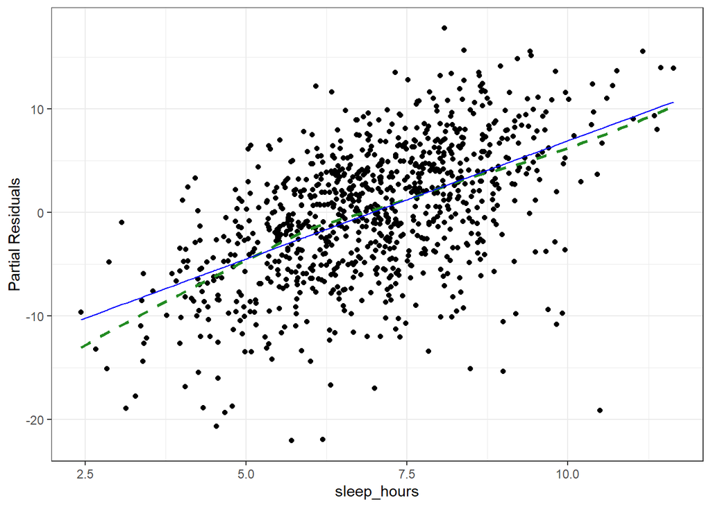

   ```r
   data_part_resid_sleep_hours_md_health <- tibble(
     sleep_hours  = data_health$sleep_hours,
     terms_sleep_hours= terms_md_health[, "sleep_hours"],
     partial_resid_sleep_hours = partial_resid_md_health[, "sleep_hours"]
   )

   ggplot(data_part_resid_sleep_hours_md_health, mapping = aes(sleep_hours, partial_resid_sleep_hours)) +
     geom_point()+
     geom_smooth(method = "loess", se = FALSE, linetype = "dashed",
                 color = "forestgreen") +
     geom_line(aes(x = sleep_hours, y = terms_sleep_hours), color = "blue") +
     labs(x = "sleep_hours", y = "Partial Residuals") +
     theme_bw()
   ```

**Kết luận:** Mối quan hệ giữa sleep_hours và phần dư là gần tuyến tính, nhưng có thể sử dụng spline để cải thiện nếu cần

6. alcohol_consumption

   ```r
   terms_md_health <- predict(md_health, type = "terms")
   head(terms_md_health)
   ```

   ```
   ##          age         bmi exercise_frequency diet_quality sleep_hours
   ## 1 -1.3627408 -7.54947926           3.900553    -8.549043   0.7675443
   ## 2  0.5836580 -4.86154949           5.726177   -16.542673   0.1094915
   ## 3 -1.8493405  0.03619985           3.900553     4.121622  -2.1388141
   ## 4 -4.2823390  4.03686519          -1.576318   -11.876455  -2.6551414
   ## 5  0.8269579 -3.57958765          -1.576318   -15.139946   2.1666275
   ## 6  0.8269579 -1.85412607          -1.576318    11.322646   1.8785344
   ##   smoking_status alcohol_consumption diet_quality:smoking_status
   ## 1       5.371186           0.5303580                  -2.1306732
   ## 2      -5.279566          -3.7338325                   0.3907841
   ## 3      -5.279566          -0.7037582                   2.5041299
   ## 4      -5.279566          -0.2655320                   0.8680001
   ## 5       5.371186           0.5253872                  -2.1306732
   ## 6      -5.279566           1.7427003                   3.2405815
   ##   sleep_hours:smoking_status
   ## 1                 -1.3807491
   ## 2                  1.3897854
   ## 3                  1.0011047
   ## 4                  0.9118435
   ## 5                 -1.3807491
   ## 6                  1.6956126
   ```

   ```r
   partial_resid_md_health <- residuals(md_health, type = "partial")
   head(partial_resid_md_health)
   ```

   ```
   ##         age         bmi exercise_frequency diet_quality sleep_hours
   ## 1 -5.537672 -11.7244100        -0.27437792    -12.72397  -3.4073865
   ## 2 -5.074076 -10.5192838         0.06844217    -22.20041  -5.5482428
   ## 3  7.772154   9.6576944        13.52204745     13.74312   7.4826805
   ## 4 -7.962011   0.3571935        -5.25598971    -15.55613  -6.3348131
   ## 5 -2.200130  -6.6066751        -4.60340548    -18.16703  -0.8604599
   ## 6  3.709838   1.0287537         1.30656168     14.20553   4.7614142
   ##   smoking_status alcohol_consumption diet_quality:smoking_status
   ## 1       1.196255           -3.644573                   -6.305604
   ## 2     -10.937301           -9.391567                   -5.266950
   ## 3       4.341928            8.917736                   12.125624
   ## 4      -8.959238           -3.945204                   -2.811672
   ## 5       2.344098           -2.501700                   -5.157761
   ## 6      -2.396687            4.625580                    6.123461
   ##   sleep_hours:smoking_status
   ## 1                  -5.555680
   ## 2                  -4.267949
   ## 3                  10.622599
   ## 4                  -2.767828
   ## 5                  -4.407837
   ## 6                   4.578492
   ```

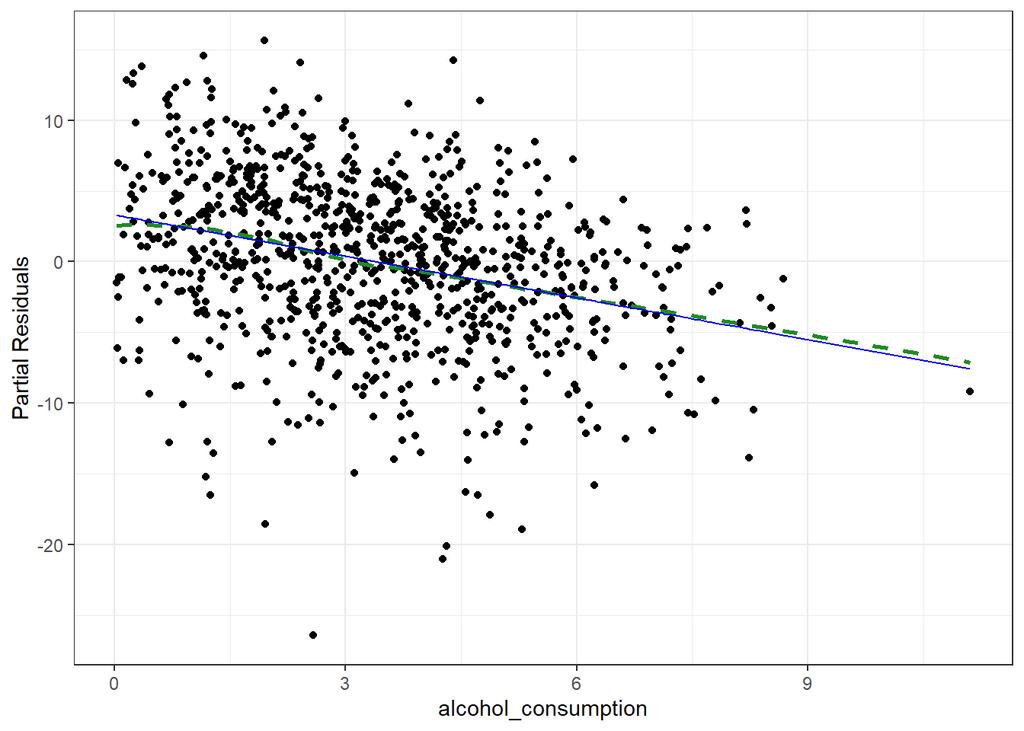

   ```r
   data_part_resid_alcohol_consumption_md_health <- tibble(
     alcohol_consumption= data_health$alcohol_consumption,
     terms_alcohol_consumption= terms_md_health[, "alcohol_consumption"],
     partial_resid_alcohol_consumption = partial_resid_md_health[, "alcohol_consumption"]
   )

   ggplot(data_part_resid_alcohol_consumption_md_health, mapping = aes(alcohol_consumption, partial_resid_alcohol_consumption)) +
     geom_point()+
     geom_smooth(method = "loess", se = FALSE, linetype = "dashed",
                 color = "forestgreen") +
     geom_line(aes(x = alcohol_consumption, y = terms_alcohol_consumption), color = "blue") +
     labs(x = "alcohol_consumption", y = "Partial Residuals") +
     theme_bw()
   ```

**Nhận xét:** Đường thẳng màu xanh thể hiện mối quan hệ tuyến tính khá tốt, nhưng có sự phi tuyến nhẹ ở các giá trị alcohol_consumption > 6. Đường cong xanh lục chỉ ra một số điểm overestimate ở phần dư.

**Kết luận:** Mối quan hệ giữa alcohol_consumption và phần dư là gần tuyến tính

### Kiểm tra tính đồng nhất phương sai

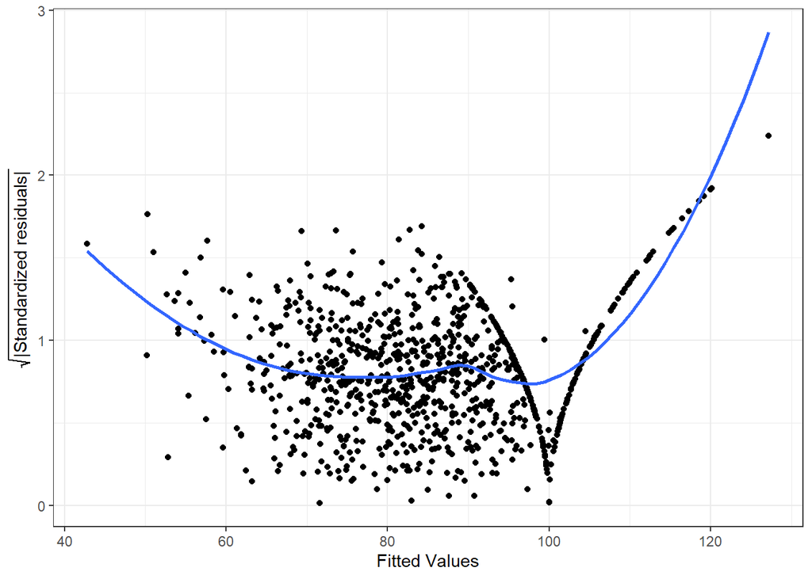

```r
ggplot(md_health, aes(.fitted, sqrt(abs(.stdresid)))) +
  geom_point(na.rm = TRUE) +
  geom_smooth(method = "loess", na.rm = TRUE, se = FALSE) +
  labs(x = "Fitted Values", y = expression(sqrt("|Standardized residuals|"))) +
  theme_bw()
```

**Nhận xét:** Đường cong màu xanh cho thấy xu hướng không đồng nhất trong phương sai của phần dư khi giá trị Fitted Values thay đổi. Phương sai giảm ở các giá trị Fitted Values thấp (khoảng 60-80). Phương sai tăng mạnh ở hai đầu (Fitted Values nhỏ hơn 60 và lớn hơn 100).

=> Các phần dư không phân tán đồng đều quanh đường ngang, cho thấy phương sai thay đổi (heteroscedasticity).

### Kiểm tra tính độc lập thặng dư

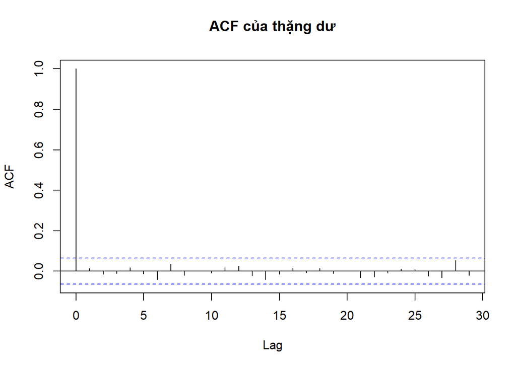

```r
residuals_md_health <- residuals(md_health)
acf(residuals_md_health, main = "ACF của thặng dư")
```

**Nhận xét:** các giá trị ACF nằm trong dải tin cậy - Thặng dư không có tương quan đáng kể

=> Đáp ứng giả định độc lập.

### Kiểm tra điểm ngoại lai trong mô hình

Sử dụng biểu đồ Residuals vs Leverage.

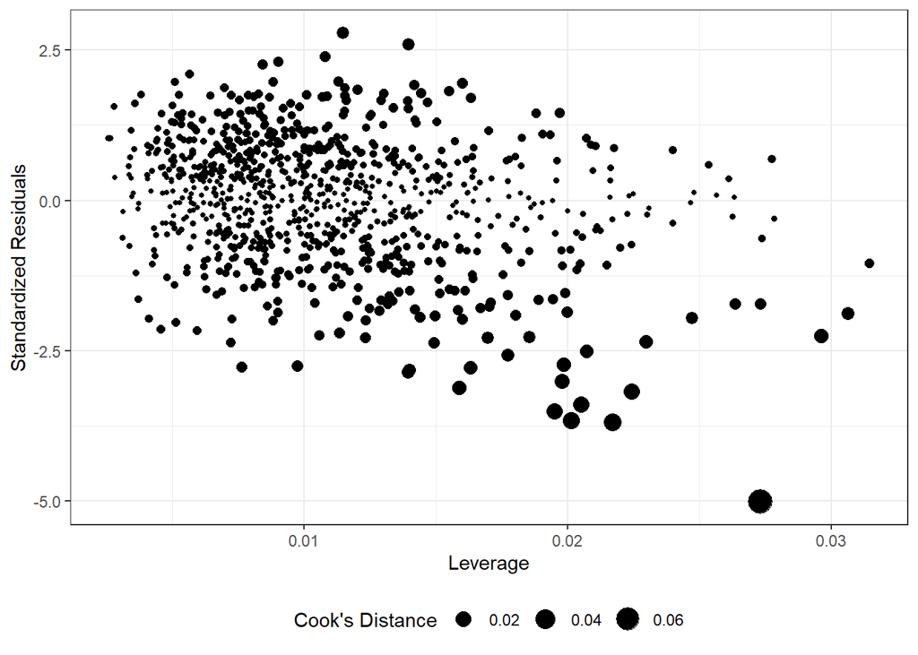

```r
ggplot(md_health, aes(.hat, .stdresid)) +
  geom_point(aes(size = .cooksd)) +
  xlab("Leverage") + ylab("Standardized Residuals") +
  scale_size_continuous("Cook's Distance", range = c(1, 6)) +
  theme_bw() +
  theme(legend.position = "bottom")
```

**Nhận xét:** Phần lớn các điểm có giá trị Cooks Distance nhỏ (< 0.02) và Phần lớn các điểm có leverage thấp (nhỏ hơn 0.015)

=> Các giá trị ngoại lai sẽ không ảnh hưởng đến mô hình hồi quy

```r
std_resid_md_health <- rstandard(md_health)
hat_values_md_health <- hatvalues(md_health)
cooks_D_md_health <- cooks.distance(md_health)

data_cooks_md_health <- tibble(id_point = 1:nrow(data_health), rstand = std_resid_md_health, hats = hat_values_md_health, cooks = cooks_D_md_health, heath_score = data_health$health_score)

data_cooks_md_health |> arrange(desc(cooks))
```

```
## # A tibble: 930 × 5
##    id_point rstand   hats  cooks heath_score
##       <int>  <dbl>  <dbl>  <dbl>       <dbl>
##  1      336  -5.01 0.0273 0.0704       100
##  2      383  -3.70 0.0217 0.0304       100
##  3      614  -3.66 0.0201 0.0275       100
##  4      554  -3.52 0.0195 0.0246       100
##  5      302  -3.40 0.0205 0.0243       100
##  6      332  -3.18 0.0224 0.0233       100
##  7      817  -3.02 0.0198 0.0184       100
##  8      893  -3.12 0.0159 0.0157        33.3
##  9      878  -2.25 0.0296 0.0154        44.6
## 10      199  -2.73 0.0198 0.0150       100
## # ℹ 920 more rows
```

## (5) Mở rộng mô hình

```r
# Xác định các nút (knots) cho các biến liên tục
knots_age <- quantile(data_health$age, probs = c(0.25, 0.5, 0.75))
knots_bmi <- quantile(data_health$bmi, probs = c(0.25, 0.5, 0.75))
knots_diet <- quantile(data_health$diet_quality, probs = c(0.25, 0.5, 0.75))
knots_sleep <- quantile(data_health$sleep_hours, probs = c(0.25, 0.5, 0.75))

# Xây dựng mô hình spline
md_health_spline <- lm(
  health_score ~ smoking_status * bs(diet_quality, knots = knots_diet, degree = 3) +
    smoking_status * bs(sleep_hours, knots = knots_sleep, degree = 3) +
    bs(age, knots = knots_age, degree = 3) +
    bs(bmi, knots = knots_bmi, degree = 3) +
    exercise_frequency + alcohol_consumption,
  data = data_health
)

# Tóm tắt mô hình spline
summary(md_health_spline)
```

```
##
## Call:
## lm(formula = health_score ~ smoking_status * bs(diet_quality,
##     knots = knots_diet, degree = 3) + smoking_status * bs(sleep_hours,
##     knots = knots_sleep, degree = 3) + bs(age, knots = knots_age,
##     degree = 3) + bs(bmi, knots = knots_bmi, degree = 3) + exercise_frequency +
##     alcohol_consumption, data = data_health)
##
## Residuals:
##     Min      1Q  Median      3Q     Max
## -22.746  -3.223   0.352   3.387  15.154
##
## Coefficients:
##                                                                    Estimate
## (Intercept)                                                        60.11604
## smoking_status1                                                    -1.06653
## bs(diet_quality, knots = knots_diet, degree = 3)1                  22.75516
## bs(diet_quality, knots = knots_diet, degree = 3)2                  28.72270
## bs(diet_quality, knots = knots_diet, degree = 3)3                  45.40728
## bs(diet_quality, knots = knots_diet, degree = 3)4                  58.20050
## bs(diet_quality, knots = knots_diet, degree = 3)5                  46.80354
## bs(diet_quality, knots = knots_diet, degree = 3)6                  67.07573
## bs(sleep_hours, knots = knots_sleep, degree = 3)1                  -5.84925
## bs(sleep_hours, knots = knots_sleep, degree = 3)2                   8.22152
## bs(sleep_hours, knots = knots_sleep, degree = 3)3                   7.21122
## bs(sleep_hours, knots = knots_sleep, degree = 3)4                  15.78550
## bs(sleep_hours, knots = knots_sleep, degree = 3)5                   9.83937
## bs(sleep_hours, knots = knots_sleep, degree = 3)6                  23.45024
## bs(age, knots = knots_age, degree = 3)1                            -9.77063
## bs(age, knots = knots_age, degree = 3)2                           -10.96839
## bs(age, knots = knots_age, degree = 3)3                           -14.57474
## bs(age, knots = knots_age, degree = 3)4                           -20.19315
## bs(age, knots = knots_age, degree = 3)5                           -21.55614
## bs(age, knots = knots_age, degree = 3)6                           -27.22757
## bs(bmi, knots = knots_bmi, degree = 3)1                             1.04742
## bs(bmi, knots = knots_bmi, degree = 3)2                            -5.04580
## bs(bmi, knots = knots_bmi, degree = 3)3                           -11.83139
## bs(bmi, knots = knots_bmi, degree = 3)4                           -18.07725
## bs(bmi, knots = knots_bmi, degree = 3)5                           -28.05608
## bs(bmi, knots = knots_bmi, degree = 3)6                           -36.53552
```

[output cut: 128 more lines]

```
## smoking_status1:bs(diet_quality, knots = knots_diet, degree = 3)4 0.226719
## smoking_status1:bs(diet_quality, knots = knots_diet, degree = 3)5 0.560523
## smoking_status1:bs(diet_quality, knots = knots_diet, degree = 3)6 0.103011
## smoking_status1:bs(sleep_hours, knots = knots_sleep, degree = 3)1 0.318707
## smoking_status1:bs(sleep_hours, knots = knots_sleep, degree = 3)2 0.446536
## smoking_status1:bs(sleep_hours, knots = knots_sleep, degree = 3)3 0.183227
## smoking_status1:bs(sleep_hours, knots = knots_sleep, degree = 3)4 0.369018
## smoking_status1:bs(sleep_hours, knots = knots_sleep, degree = 3)5 0.105745
## smoking_status1:bs(sleep_hours, knots = knots_sleep, degree = 3)6 0.801079
## ---
## Signif. codes:  0 '***' 0.001 '**' 0.01 '*' 0.05 '.' 0.1 ' ' 1
##
## Residual standard error: 5.073 on 890 degrees of freedom
## Multiple R-squared:  0.8704, Adjusted R-squared:  0.8647
## F-statistic: 153.3 on 39 and 890 DF,  p-value: < 2.2e-16
```

```r
# Mô hình tuyến tính cơ bản
md_health_linear <- lm(health_score ~ smoking_status * diet_quality +
                         smoking_status * sleep_hours + age + bmi +
                         exercise_frequency + alcohol_consumption,
                       data = data_health)


# So sánh R-squared và AIC
cat("Linear model R-squared:", summary(md_health_linear)$r.squared, "\n")
```

```
## Linear model R-squared: 0.8418506
```

```r
cat("Spline model R-squared:", summary(md_health_spline)$r.squared, "\n")
```

```
## Spline model R-squared: 0.870405
```

```r
cat("Linear model AIC:", AIC(md_health_linear), "\n")
```

```
## Linear model AIC: 5826.149
```

```r
cat("Spline model AIC:", AIC(md_health_spline), "\n")
```

```
## Spline model AIC: 5700.962
```

**Nhận xét:** Sau khi dùng Splines để cải thiện các mối quan hệ phi tuyến nhẹ thì ta thấy có sự cải thiện ở chỉ số R-squared và AIC cho thấy Splines có hiệu quả tốt hơn.

## (6) Suy luận cho mô hình

### Ước lượng của hệ số bằng phương pháp boostrap

```r
fun_boot_md <- function(data, ind, formula, ...){
data_new <- data[ind,]
out_md <- lm(formula = formula, data = data_new, ...)
return(out_md$coefficients)
}

library(boot)
set.seed(84)
md_health = lm(health_score ~ age+bmi+exercise_frequency+diet_quality+sleep_hours+smoking_status+ alcohol_consumption,data = data_health)
out_boot_md_health <- boot(data = data_health, statistic = fun_boot_md, R = 1000,
formula =  health_score ~ age+bmi+exercise_frequency+diet_quality+sleep_hours+smoking_status+ alcohol_consumption)
out_boot_md_health
```

```
##
## ORDINARY NONPARAMETRIC BOOTSTRAP
##
##
## Call:
## boot(data = data_health, statistic = fun_boot_md, R = 1000, formula = health_score ~
##     age + bmi + exercise_frequency + diet_quality + sleep_hours +
##         smoking_status + alcohol_consumption)
##
##
## Bootstrap Statistics :
##       original        bias    std. error
## t1* 62.9869457  6.342061e-02  1.79732211
## t2* -0.2449801 -4.003239e-04  0.01601517
## t3* -1.1315121  8.158350e-04  0.04229274
## t4*  1.8315190 -1.218303e-03  0.09642900
## t5*  0.6181588 -2.283203e-04  0.01445393
## t6*  2.4985557 -5.241158e-03  0.13161999
## t7* -3.6848843  3.196740e-03  0.36605529
## t8* -0.9805444 -9.452443e-05  0.09675339
```

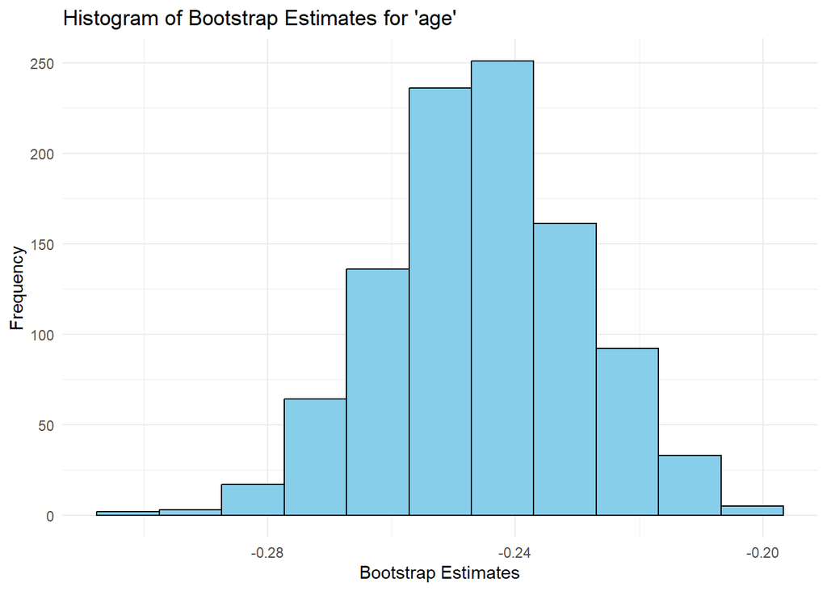

```r
# Trích xuất kết quả bootstrap của các hệ số
boot_coefficients <- as.data.frame(out_boot_md_health$t)
names(boot_coefficients) <- names(coef(md_health))

# Tính độ rộng binwidth cho từng hệ số
n=10 #chia histogram thành 10 khoảng
binwidth_age <- (max(boot_coefficients$age) - min(boot_coefficients$age)) / n
binwidth_bmi <- (max(boot_coefficients$bmi) - min(boot_coefficients$bmi)) /n
binwidth_exercise_frequency <- (max(boot_coefficients$exercise_frequency) - min(boot_coefficients$exercise_frequency)) / n
binwidth_diet_quality <- (max(boot_coefficients$diet_quality) - min(boot_coefficients$diet_quality)) /n
binwidth_sleep_hours <- (max(boot_coefficients$sleep_hours) - min(boot_coefficients$sleep_hours)) /n
binwidth_smoking_status <- (max(boot_coefficients$smoking_status) - min(boot_coefficients$smoking_status)) /n
binwidth_alcohol_consumption <- (max(boot_coefficients$alcohol_consumption) - min(boot_coefficients$alcohol_consumption))


# Histogram cho hệ số 'age'
ggplot(boot_coefficients, aes(x = age)) +
  geom_histogram(binwidth = binwidth_age, fill = "skyblue", color = "black") +
  theme_minimal() +
  labs(title = "Histogram of Bootstrap Estimates for 'age'",
       x = "Bootstrap Estimates",
       y = "Frequency")
```

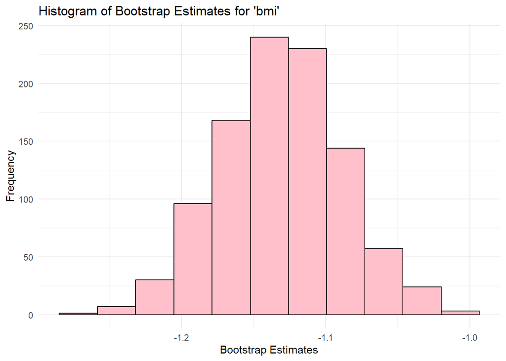

```r
# Histogram cho hệ số 'bmi'
ggplot(boot_coefficients, aes(x = bmi)) +
  geom_histogram(binwidth = binwidth_bmi, fill = "pink", color = "black") +
  theme_minimal() +
  labs(title = "Histogram of Bootstrap Estimates for 'bmi'",
       x = "Bootstrap Estimates",
       y = "Frequency")
```

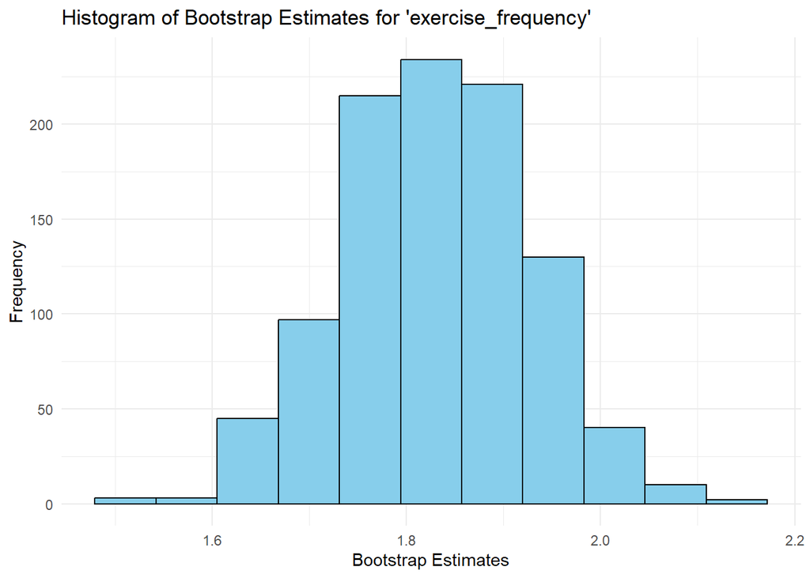

```r
ggplot(boot_coefficients, aes(x = exercise_frequency)) +
  geom_histogram(binwidth = binwidth_exercise_frequency, fill = "skyblue", color = "black") +
  theme_minimal() +
  labs(title = "Histogram of Bootstrap Estimates for 'exercise_frequency'",
       x = "Bootstrap Estimates",
       y = "Frequency")
```

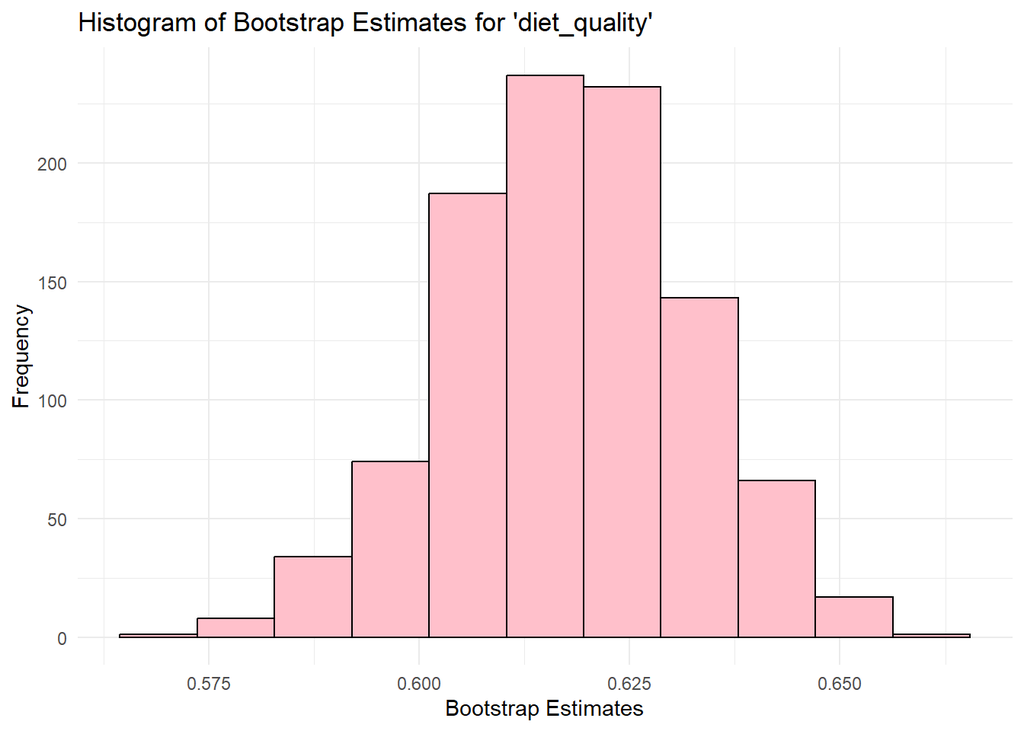

```r
ggplot(boot_coefficients, aes(x = diet_quality)) +
  geom_histogram(binwidth = binwidth_diet_quality, fill = "pink", color = "black") +
  theme_minimal() +
  labs(title = "Histogram of Bootstrap Estimates for 'diet_quality'",
       x = "Bootstrap Estimates",
       y = "Frequency")
```

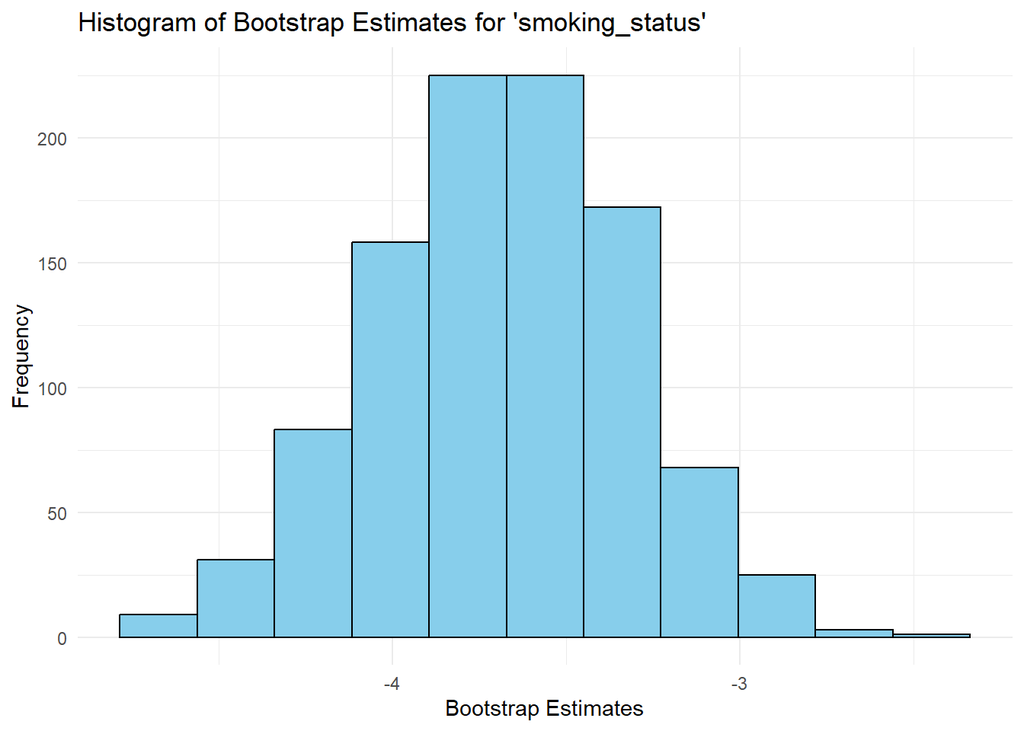

```r
ggplot(boot_coefficients, aes(x = smoking_status1)) +
  geom_histogram(binwidth = binwidth_smoking_status, fill = "skyblue", color = "black") +
  theme_minimal() +
  labs(title = "Histogram of Bootstrap Estimates for 'smoking_status'",
       x = "Bootstrap Estimates",
       y = "Frequency")
```

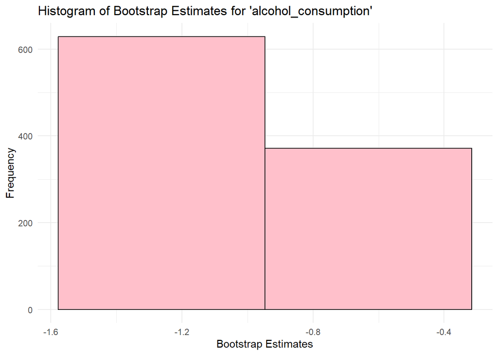

```r
ggplot(boot_coefficients, aes(x = alcohol_consumption)) +
  geom_histogram(binwidth = binwidth_alcohol_consumption, fill = "pink", color = "black") +
  theme_minimal() +
  labs(title = "Histogram of Bootstrap Estimates for 'alcohol_consumption'",
       x = "Bootstrap Estimates",
       y = "Frequency")
```

```r
boot.ci(out_boot_md_health, index = 1, type = "perc", conf = 0.95)
```

```
## BOOTSTRAP CONFIDENCE INTERVAL CALCULATIONS
## Based on 1000 bootstrap replicates
##
## CALL :
## boot.ci(boot.out = out_boot_md_health, conf = 0.95, type = "perc",
##     index = 1)
##
## Intervals :
## Level     Percentile
## 95%   (59.63, 66.47 )
## Calculations and Intervals on Original Scale
```

```r
boot.ci(out_boot_md_health, index = 2, type = "perc", conf = 0.95)
```

```
## BOOTSTRAP CONFIDENCE INTERVAL CALCULATIONS
## Based on 1000 bootstrap replicates
##
## CALL :
## boot.ci(boot.out = out_boot_md_health, conf = 0.95, type = "perc",
##     index = 2)
##
## Intervals :
## Level     Percentile
## 95%   (-0.2769, -0.2135 )
## Calculations and Intervals on Original Scale
```

```r
boot.ci(out_boot_md_health, index = 3, type = "perc", conf = 0.95)
```

```
## BOOTSTRAP CONFIDENCE INTERVAL CALCULATIONS
## Based on 1000 bootstrap replicates
##
## CALL :
## boot.ci(boot.out = out_boot_md_health, conf = 0.95, type = "perc",
##     index = 3)
##
## Intervals :
## Level     Percentile
## 95%   (-1.216, -1.044 )
## Calculations and Intervals on Original Scale
```

```r
boot.ci(out_boot_md_health, index = 4, type = "perc", conf = 0.95)
```

```
## BOOTSTRAP CONFIDENCE INTERVAL CALCULATIONS
## Based on 1000 bootstrap replicates
##
## CALL :
## boot.ci(boot.out = out_boot_md_health, conf = 0.95, type = "perc",
##     index = 4)
##
## Intervals :
## Level     Percentile
## 95%   ( 1.634,  2.011 )
## Calculations and Intervals on Original Scale
```

```r
boot.ci(out_boot_md_health, index = 5, type = "perc", conf = 0.95)
```

```
## BOOTSTRAP CONFIDENCE INTERVAL CALCULATIONS
## Based on 1000 bootstrap replicates
##
## CALL :
## boot.ci(boot.out = out_boot_md_health, conf = 0.95, type = "perc",
##     index = 5)
##
## Intervals :
## Level     Percentile
## 95%   ( 0.5884,  0.6458 )
## Calculations and Intervals on Original Scale
```

```r
boot.ci(out_boot_md_health, index = 6, type = "perc", conf = 0.95)
```

```
## BOOTSTRAP CONFIDENCE INTERVAL CALCULATIONS
## Based on 1000 bootstrap replicates
##
## CALL :
## boot.ci(boot.out = out_boot_md_health, conf = 0.95, type = "perc",
##     index = 6)
##
## Intervals :
## Level     Percentile
## 95%   ( 2.229,  2.748 )
## Calculations and Intervals on Original Scale
```

```r
boot.ci(out_boot_md_health, index = 7, type = "perc", conf = 0.95)
```

```
## BOOTSTRAP CONFIDENCE INTERVAL CALCULATIONS
## Based on 1000 bootstrap replicates
##
## CALL :
## boot.ci(boot.out = out_boot_md_health, conf = 0.95, type = "perc",
##     index = 7)
##
## Intervals :
## Level     Percentile
## 95%   (-4.417, -2.983 )
## Calculations and Intervals on Original Scale
```

Tiếp theo, chúng ta kiểm định giả thuyết βj = 0, như sau:

```r
pvals_adv2 <- sapply(1:ncol(out_boot_md_health$t),function(x) {
qt0 <- mean(out_boot_md_health$t[, x] <= 0)
if (qt0 < 0.5) {
return(2*qt0)
} else {
return(2*(1 - qt0))
}
})
pvals_adv2
```

```
## [1] 0 0 0 0 0 0 0 0
```

## (7) Tiên đoán

```r
# Tiên đoán thử nghiệm cho mô hình từ một mẫu ngẫu nhiên

new_data <- data.frame(
  age = 30,
  bmi = 25,
  exercise_frequency = 3,
  diet_quality = 70,
  sleep_hours = 7,
  smoking_status = factor(0, levels = levels(data_health$smoking_status)), # Chuyển đổi thành factor
  alcohol_consumption = 2
)

# Tiến hành dự đoán
y_hat <- predict(md_health_spline, newdata = new_data)
y_hat
```

```
##        1
## 93.29813
```

```r
# Khoảng tin cậy boostrap
set.seed(123) # Để đảm bảo tính tái lập
R <- 1000
bootstrap_means <- replicate(R, {
  sample_indices <- sample(1:nrow(data_health), replace = TRUE)
  bootstrap_data <- data_health[sample_indices, ]
  bootstrap_model <- lm(health_score ~ age + bmi + exercise_frequency + diet_quality +
                          sleep_hours + smoking_status + alcohol_consumption,
                        data = bootstrap_data)
  predict(bootstrap_model, newdata = new_data)
})

# Khoảng tin cậy 95%
quantile(bootstrap_means, probs = c(0.025, 0.975))
```

```
##     2.5%    97.5%
## 90.90463 92.32925
```

Khoảng tin cậy khá hẹp, cho thấy sự chính xác của việc ước lượng giá trị trung bình tổng thể.

Điều này có thể ngụ ý rằng mẫu dữ liệu được lấy khá đại diện cho tổng thể, hoặc độ dao động của dữ liệu là tương đối thấp.

```r
# Khoảng dự đoán boostrap
set.seed(123)
bootstrap_predictions <- replicate(R, {
  sample_indices <- sample(1:nrow(data_health), replace = TRUE)
  bootstrap_data <- data_health[sample_indices, ]
  bootstrap_model <- lm(health_score ~ age + bmi + exercise_frequency + diet_quality +
                          sleep_hours + smoking_status + alcohol_consumption,
                        data = bootstrap_data)
  y_hat <- predict(bootstrap_model, newdata = new_data)
  residual <- sample(residuals(bootstrap_model), size = 1, replace = TRUE)
  y_hat + residual
})

# Khoảng dự đoán 95%
quantile(bootstrap_predictions, probs = c(0.025, 0.975))
```

```
##      2.5%     97.5%
##  80.24208 100.93365
```

Khoảng dự đoán rộng hơn nhiều so với khoảng tin cậy, phản ánh sự biến động lớn hơn ở cấp độ từng quan sát so với giá trị trung bình.

Điều này là do khoảng dự đoán phải tính đến cả phương sai của tổng thể và sai số của từng điểm dữ liệu, khiến khoảng này rộng hơn.

**Nhận xét:** Nếu cần xác định giá trị trung bình của tổng thể, chúng ta dựa vào khoảng tin cậy. Ngược lại, nếu muốn dự đoán giá trị cụ thể trong tương lai, khoảng dự đoán sẽ được sử dụng.

# 3. Viết các nhận xét và kết luận.

**Kết luận:** Lời khuyên: Khuyến khích chế độ ăn uống lành mạnh và giấc ngủ hợp lý. Hạn chế tiêu thụ rượu bia và giảm chỉ số BMI thông qua tập thể dục đều đặn. Phân tích sâu hơn: Chúng ta có thể Nghiên cứu thêm về tương tác của hút thuốc và các yếu tố khác để có cái nhìn rõ hơn. Xem xét các mô hình phi tuyến khác để xác nhận kết quả